# Fourier Series

Introductory Examples

Send comments to: Tony T (tthrall)

2025-05-12 19:10 BST

Abstract

Introduce the Fourier series approximation of a function as demonstrated by a few periodic, piecewise linear functions.

## Approximation Framework

### Motivation

This technical note introduces the Fourier series approximation of $2 \pi$-periodic functions as a starting point for the Fourier analysis of times seris (to be introduced in a separate technical note).

### $L_p(\mathbb{T})$

#### Definition

Let $\mathbb{T} = \{ \omega \in \mathbb{C}: | \omega | = 1 \}$ denote the multiplicative, topological group of complex numbers of modulus 1, whose basic open sets are open arcs of the unit circle.

Let $\lambda_\mathbb{T}$ denote Lebesgue measure on $\mathbb{T}$ divided by $2 \pi$ so that $\lambda_\mathbb{T} (\mathbb{T}) = 1$.

For any $p \ge 1$ define $L_p(\mathbb{T})$ to be the linear space of measurable, complex-valued functions $\phi: \mathbb{T} \rightarrow \mathbb{C}$ such that

$$\begin{align}
\phi \in L_p(\mathbb{T}) &\Leftrightarrow \int_\mathbb{T} | \phi
|^p d\mu < \infty
\end{align}$$

We then define the following norm on $L_p(\mathbb{T})$.

$$\begin{align}
{\lVert \phi \rVert}_p &= \left ( \int_\mathbb{T} | \phi |^p d\mu
\right )^{ \frac {1}{p}}
\end{align}$$

This definition for finite $p$ can be extended to the norm ${\lVert \phi \rVert}_\infty$ as follows. Given $\phi: \mathbb{T} \rightarrow \mathbb{C}$ define $U_\phi$ to be the following subset of non-negative bounds $b$ (if any) such that

$$\begin{align}
b \in U_\phi &\Leftrightarrow \mu \left ( \{ \omega: | \phi
(\omega) | > b \} \right ) = 0
\end{align}$$

Then we define

$$\begin{align}
{\lVert \phi \rVert}_\infty &=
\begin{cases}
\infty & \text{if } U_\phi = \emptyset \\
\inf \; {U_\phi} & \text{otherwise}
\end{cases}
\end{align}$$

This norm is called the *essential upper bound* of $| \phi(\cdot) |$. If ${\lVert \phi \rVert}_\infty < \infty$, $\phi(\cdot)$ is said to be *essentially bounded*. The normed linear space of essentially bounded functions is denoted $L_\infty(\mathbb{T})$.

It turns out that for each $p \in [1, \infty]$, $L_p(\mathbb{T})$ is a *complete* normed linear space i.e., a Banach space. That is, each Cauchy sequence in $L_p(\mathbb{T})$ converges to a member of $L_p(\mathbb{T})$.

#### $2 \pi$-periodic functions

For $\omega \in \mathbb{T}$ let $\omega \mapsto \theta_{(\omega)}$ denote the *principal argument* of $\omega$

$$\begin{align}
\theta_{(\omega)} = \text{Arg } (\omega) \in (- \pi, \pi]
\end{align}$$

so that

$$\begin{align}
\omega = \exp (i \; \theta_{(\omega)}) = e^{i \; \theta_{(\omega)}}
\end{align}$$

Conversely, given $\theta \in \mathbb{R}$ let $\tilde{\theta}$ denote the following modular mapping from $\mathbb{R}$ to $(- \pi, \pi]$

$$\begin{align}
\tilde{\theta} = \text{Arg } ( e^{i \theta} ) \in (- \pi, \pi]
\end{align}$$

and let $\theta \mapsto \omega_{(\theta)}$ denote the related mapping from $\mathbb{R}$ to $\mathbb{T}$.

$$\begin{align}
\omega_{(\theta)} = e^{i \; \theta}
\end{align}$$

A function $f: \mathbb{R} \rightarrow \mathbb{C}$ is periodic with period $2 \pi$ if

$$\begin{align}
f(\theta) &= f(\tilde{\theta}) & \text{for all } \theta \in
\mathbb{R}
\end{align}$$

In this case we identify $f: \mathbb{R} \rightarrow \mathbb{C}$ with a corresponding function $\phi: \mathbb{T} \rightarrow \mathbb{C}$ for which

$$\begin{align}
f(\theta) &= \phi(e^{i \theta}) & \text{for all } \theta \in
\mathbb{R}
\end{align}$$

so that

$$\begin{align}
f(\theta) &= \phi(\omega_{(\theta)}) \\
\phi(\omega) &= f(\theta_{(\omega)})
\end{align}$$

That is, $f(\cdot)$ can be identified with a given $\phi(\cdot)$ or, alternatively, $\phi(\cdot)$ can be identified with a given $f(\cdot)$. We denote this equivalence as $f \equiv \phi$ and we define

$$\begin{align}
\lVert f \rVert_p &= \lVert \phi \rVert_p & \text{whenever } f
\equiv \phi
\end{align}$$

for all $p \in [1, \infty]$.

#### Inclusion relations

Since $\lambda(\mathbb{T})$ is finite (and moreover equal to unity), we can show that for all finite $p > 0$ we have ${\lVert \phi \rVert}_p \le {\lVert \phi \rVert}_\infty$.

$$\begin{align}
{\lVert \phi \rVert}_p &= \left ( \int_\mathbb{T} | \phi (\omega)
|^p d\mu (\omega) \right )^{ \frac {1}{p}} \\
&\le \left ( \int_\mathbb{T} {\lVert \phi \rVert}_\infty^p d\mu
(\omega) \right )^{ \frac {1}{p}} \\
&= {\lVert \phi \rVert}_\infty \left ( \int_\mathbb{T} 1 \; d\mu
(\omega) \right )^{ \frac {1}{p}} \\
&= {\lVert \phi \rVert}_\infty \left ( \mu(\mathbb{T}) \right )^{
\frac {1}{p}} \\
&= {\lVert \phi \rVert}_\infty
\end{align}$$

If ${\lVert \phi \rVert}_p = {\lVert \phi \rVert}_\infty$, then either both ${\lVert \phi \rVert}_p$ and ${\lVert \phi \rVert}_\infty$ are infinite, or else $\left | \phi(\omega) \right | = {\lVert \phi \rVert}_\infty$ for almost all $\omega$. Otherwise ${\lVert \phi \rVert}_p < {\lVert \phi \rVert}_\infty$.

Moreover, if $0 < p < q < \infty$ then

$$\begin{align}
{\lVert \phi \rVert}_p^p &= \int_\mathbb{T} | \phi(\omega) |^p d\mu
(\omega) \\
&= \int_{| \phi | \le 1} | \phi(\omega) |^p d\mu (\omega) +
\int_{| \phi | > 1} | \phi(\omega) |^p d\mu (\omega) \\
&\le \int_{| \phi | \le 1} 1 \; d\mu (\omega) + \int_{| \phi |
> 1} | \phi(\omega) |^p d\mu (\omega) \\
&\le \int_{| \phi | \le 1} 1 \; d\mu (\omega) + \int_{| \phi |
> 1} | \phi(\omega) |^q d\mu (\omega) \\
&\le \int_\mathbb{T} 1 \; d\mu (\omega) + \int_\mathbb{T} |
\phi(\omega) |^q d\mu (\omega) \\
&= 1+ {\lVert \phi \rVert}_q^q
\end{align}$$

Consequently if ${\lVert \phi \rVert}_q$ is finite then so must be ${\lVert \phi \rVert}_p$. That is, if $\phi (\cdot)$ is a member of $L_q(\mathbb{T})$ then it must also be a member of $L_p(\mathbb{T})$. We thus have the following chain of subsets among these normed linear spaces.

$$\begin{align}
L_\infty(\mathbb{T}) \subset L_q(\mathbb{T}) \subset L_p(\mathbb{T})
\subset L_1(\mathbb{T}) \\
\\
\text{for } 1 < p < q < \infty
\end{align}$$

### $L_2(\mathbb{T})$

#### Inner product

For any $\phi, \eta \in L_2(\mathbb{T})$ we define the following inner product.

$$\begin{align}
\left < \phi, \eta \right > &= \int_\mathbb{T} \phi \times
\bar{\eta} \; d\lambda_\mathbb{T} \\
&= \frac{1}{2 \pi} \int_{- \pi}^{\pi} \phi(e^{i \theta}) \times
\bar{\eta}(e^{i \theta}) \; d\theta
\end{align}$$

By the Cauchy-Schwarz-Bunyakovsky inequality we have

$$\begin{align}
\left | \left < \phi, \eta \right > \right |
&le {\lVert \phi \rVert}_2 \; {\lVert \eta \rVert}_2
\end{align}$$

Like other $L_p(\mathbb{T})$ spaces, $L_2(\mathbb{T})$ is a complete normed space, that is, a Banach space. Consequently, $L_2(\mathbb{T})$ is also complete inner product space, that is, a Hilbert space.

#### An orthonormal basis

For each integer $\nu \in \mathbb{Z}$ define function $u_\nu: \mathbb{T} \rightarrow \mathbb{C}$ as follows.

$$\begin{align}
u_\nu(\omega) = {\omega}^\nu
\end{align}$$

or equivalently

$$\begin{align}
u_\nu(e^{i \theta}) = e^{i \nu \theta}
\end{align}$$

Then $\left | u_\nu (\omega) \right | = 1$ for all $\omega \in \mathbb{T}$ so that $\Vert u_\nu \rVert_\infty = 1$ and thus $u_\nu (\cdot)$ is a member of $L_p(\mathbb{T})$ for all $p \in [1, \infty]$. In particular $u_\nu \in L_2(\mathbb{T})$.

Now for any integers $\mu, \nu \in \mathbb{Z}$ the pair of functions $u_\mu, u_\nu$ have the following inner product.

$$\begin{align}
\left < u_\mu, u_\nu \right > &= \int_\mathbb{T} u_\mu
\times \bar{u}_\nu \; d\lambda_\mathbb{T} \\
&= \frac{1}{2 \pi} \int_{- \pi}^{\pi} u_\mu(e^{i \theta}) \times
\bar{u}_\nu(e^{i \theta}) \; d\theta \\
&= \frac{1}{2 \pi} \int_{- \pi}^{\pi} e^{i \mu \theta} \times
e^{-i \nu \theta} \; d\theta \\
&= \frac{1}{2 \pi} \int_{- \pi}^{\pi} e^{i \theta (\mu - \nu) } \;
d\theta \\
&= 1_{[0]}[\mu - \nu] \\
&=
\begin{cases}
1 & \text{if } \mu - \nu = 0 \\
0 & \text{otherwise}
\end{cases}
\end{align}$$

Therefore

$$\begin{align}
\left \{ u_\nu(\cdot) \right \}_{\nu = - \infty}^\infty
\end{align}$$

is an orthonormal set of functions in $L_2(\mathbb{T})$. Moreover, it turns out this set is an orthonormal *basis* of $L_2(\mathbb{T})$. That is, each member of $L_2(\mathbb{T})$ can be approximated arbitrarily closely in the 2-norm by a finite linear combination from this set of functions.

### Linear functionals

#### $\mathcal{B}^*$

Let $\mathcal{B}$ be a Banach space of complex-valued functions defined on $\mathbb{T}$, with the norm of function $f(\cdot)\in \mathcal{B}$ denoted as $\Vert f \rVert_\mathcal{B}$.

A *linear functional* on $\mathcal{B}$ is a complex-valued linear mapping $\lambda: \mathcal{B} \rightarrow \mathbb{C}$. The linear functional $\lambda$ is said to be *bounded* if there is some constant $b \ge 0$ such that

$$\begin{align}
\left | \lambda(f) \right | &\le b \; \lVert f \rVert_\mathcal{B}
& \text{for all } f \in \mathcal{B}
\end{align}$$

Now let $U_\lambda$ denote the set of all such bounds $b$.

$$\begin{align}
b \in U_\lambda & \Leftrightarrow \left | \lambda(f) \right |
\le b \; \lVert f \rVert_\mathcal{B} & \text{for all } f \in
\mathcal{B}
\end{align}$$

Then the bounded linear functionals consitute a Banach space, in which the norm of $\lambda$ is defined to be the infimum of all such bounds $b$.

$$\begin{align}
\lVert \lambda \rVert &= \inf \; \left ( U_\lambda \right )
\end{align}$$

(As usual, we define the infimum of the empty set to be infinity. If $U_\lambda = \emptyset$ we define $\lVert \lambda \rVert = \infty$.)

The normed linear space of bounded linear functionals is called the *dual space* of $\mathcal{B}$, and is denoted as $\mathcal{B}^*$.

#### $L_p(\mathbb{T})^*$

Recall *Hölder’s inequality*. For each $p \in (1, \infty)$ define $q = p / (p-1)$ to be the Hölder conjugate exponent of $p$. Then

$$\begin{align}
\frac{1}{p} + \frac{1}{q} = 1
\end{align}$$

Extend this set of conjugate pairs to include $(p, q) = (1, \infty)$. Then for $f \in L_p(\mathbb{T})$ and $g \in L_q(\mathbb{T})$, the point-wise product $f(\theta) \times g(\theta)$ is a member of $L_1(\mathbb{T})$ and satisfies Hölder’s inequality:

$$\begin{align}
\lVert f \; g \rVert_1 &\le \lVert f \rVert_p \; \lVert g \rVert_q
\end{align}$$

Consequently the mapping

$$\begin{align}
\lambda_g(f) &= \int_\mathbb{T} f(\theta_\omega) \;
g(\theta_\omega) \; d\lambda_\mathbb{T} (\omega) \\
&= \frac{1}{2 \pi} \int_{- \pi}^\pi f(\theta) \; g(\theta) \;
d\theta
\end{align}$$

is a bounded linear functional with norm $\Vert g \rVert_q$.

$$\begin{align}
\lVert \lambda_g \rVert &= \lVert g \rVert_q
\end{align}$$

Thus the map

$$\begin{align}
g \mapsto \lambda_g \in L_p(\mathbb{T})^*
\end{align}$$

embeds $L_q(\mathbb{T})$ in $L_p(\mathbb{T})^*$. This embedding turns out to be an isometric isomorphism.

$$\begin{align}
L_p(\mathbb{T})^* & \equiv L_q(\mathbb{T})
\end{align}$$

Summarizing, we have

$$\begin{align}
\lambda_g(f) &= \frac{1}{2 \pi} \int_{- \pi}^\pi f(\theta) \;
g(\theta) \; d\theta \\
\\
& \text{for } f \in L_p(\mathbb{T}) \text{ and } g \in
L_q(\mathbb{T}) \\
\\
& \text{with } \frac{1}{p} \; + \; \frac{1}{p} = 1
\end{align}$$

#### $\mathcal{C}(\mathbb{T})^*$

From the preceding section note that as $p \in [1, \infty]$ increases, the domain $L_p(\mathbb{T})$ becomes more restrictive, thereby enlarging the dual space of bounded linear functionals $\lambda_g \in L_p(\mathbb{T})^* \equiv L_q(\mathbb{T})$.

Further restriction of this domain enlarges the corresponding dual space of linear functionals. That is for a domain Banach space $\mathcal{B}$ of bounded functions on $\mathbb{T}$ we have

$$\begin{align}
\mathcal{B} \subset L_\infty(\mathbb{T}) \\
\Rightarrow & \mathcal{B}^* \supset L_\infty(\mathbb{T})^* \equiv
L_1(\mathbb{T})
\end{align}$$

For example consider $\mathcal{B} = \mathcal{C}(\mathbb{T})$, the Banach space of continuous functions on $\mathbb{T}$ equipped with the $L_\infty(\mathbb{T})$ norm. For such well-behaved functions the Dirac delta functional, $\delta_\tau(\cdot)$ that evaluates any given function $f(\cdot) \in \mathcal{C}(\mathbb{T})$ at a specified point $\tau$ is well-defined, and moreover, bounded.

$$\begin{align}
\delta_\tau (f) &= f(\tau) \\
\\
\lVert \delta_\tau \rVert &= 1
\end{align}$$

This linear functional can be represented as the integral of $f(\cdot)$ with respect to the atomic (discrete) measure concentrated on the atom $\tau$, that is, on the singleton set $\{ \tau \}$, where it assigns unit mass.

In general, an element of $\mathcal{C}(\mathbb{T})^*$ can be represented by a complex-valued, finite measure $\mu$ on $\mathbb{T}$ so that

$$\begin{align}
\lambda_\mu (f) &= \int_\mathbb{T} f(\theta_\omega) \;
d\mu(\omega)
\end{align}$$

Each such measure $\mu$ has a discrete component $\mu_d$ and an absolutely continuous component $\mu_c$ (i.e., absolutely continuous with respect to the scaled Lebesgue measure $\lambda_\mathbb{T}$). That is, for any Borel subset $E \subseteq \mathbb{T}$ we have

$$\begin{align}
\mu (E) &= \mu_c (E) \; + \; \mu_d (E)
\end{align}$$

with

$$\begin{align}
\mu_c (E) &= \int_E g_\mu(\theta_\omega) \; d\lambda_\mathbb{T}
(\omega) \\
\\
\mu_d (E) &= \sum_{ \tau \in E \; \cap \; \sigma(\mu_d) }
\rho_\tau \; e^{i \theta_\tau}
\end{align}$$

where $\sigma (\mu_d)$ denotes the support (the set of atoms) of the discrete measure $\mu_d$, and where $\rho_\tau$ and $\theta_\tau$ are the respective modulus and argument of $\mu_d$ evaluated at such an atom $\tau$.

$$\begin{align}
\rho_\tau &= \left | \; \mu_d( \{ \tau \} ) \; \right | \\
\theta_\tau &= \text{Arg} \left ( \; \mu_d( \{ \tau \} ) \; \right
) \\
\mu_d( \{ \tau \} ) &= \rho_\tau \; e^{i \theta_\tau}
\end{align}$$

Also associated with measure $\mu$ is the corresponding modulus measure measure $| \mu |$, which is a finite, non-negative measure such that for any Borel subset $E \subseteq \mathbb{T}$ we have

$$\begin{align}
| \mu | \; (E) &= \int_E \left | g_\mu(\theta_\omega) \right | \;
d\lambda_\mathbb{T} (\omega) \;
+ \sum_{ \tau \in E \; \cap \; \sigma(\mu_d) } \rho_\tau \\
& < \infty
\end{align}$$

Since the sum of $\{ \rho_\tau \}$ across atoms $\tau$ must be finite, the set of atoms, $\sigma (\mu_d)$, can be at most countably infinite.

The norm of such a measure $\mu$ is $| \mu | (\mathbb{T})$.

$$\begin{align}
\lVert \mu \rVert &= | \mu | \; (\mathbb{T}) \\
&= \int_\mathbb{T} \left | g_\mu (\theta_\omega) \right | \;
d\lambda_\mathbb{T} (\omega) \;
+ \sum_{ \tau \in \sigma(\mu_d) } \rho_\tau \\
&= { \lVert g_\mu \rVert }_1 \; + \; | \mu_d | \; (\mathbb{T}) \\
&= { \lVert g_\mu \rVert }_1 \; + \; \lVert \mu_d \rVert \\
&< \infty
\end{align}$$

The linear functional $\lambda_\mu$ evaluated at $f(\cdot)$ is thus

$$\begin{align}
\lambda_\mu (f) &= \int_\mathbb{T} f(\theta_\omega) \;
d\mu(\omega) \\
&= \int_\mathbb{T} f(\theta_\omega) \; d\mu_c(\omega) \;
+ \; \int_\mathbb{T} f(\theta_\omega) \; d\mu_d(\omega) \\
&= \frac{1}{2 \pi} \int_0^{2 \pi} f(\theta) \; g(\theta) \;
d\theta \;
+ \; \sum_{ \tau \in \sigma(\mu_d) } f(\tau) \; \rho_\tau \; e^{i
\theta_tau}
\end{align}$$

The linear functional $\lambda_mu$ has the norm of its corresponding measure $\mu$.

$$\begin{align}
\lVert \lambda \rVert &= \lVert \mu \rVert
\end{align}$$

Summarizing, we have

$$\begin{align}
\mathcal{C}(\mathbb{T})^* = \mathcal{M} (\mathbb{T})
\end{align}$$

where $\mathcal{M} (\mathbb{T})$ denotes the Banach space of finite, complex-valued Borel measures $\mu (\cdot)$ defined on $\mathbb{T}$.

#### $\mathcal{C}_m (\mathbb{T})^*$

Suppose the domain $\mathcal{B}$ is now further restricted to $\mathcal{C}_m (\mathbb{T})$, the set of functions whose $m^{th}$ derivative exists and is continuous (thus bounded) on $\mathbb{T}$. Then the dual space of functionals that are well-defined and bounded on this restricted domain is expanded to $\mathcal{D}_m (\mathbb{T})$, the generalized functions (Schwartz distributions) of order $m$. One such functional is $f^{(m)} (\tau)$, the $m^{th}$ derivative of $f(\cdot)$ evaluated at some specified point $\tau$.

## Fourier Coefficients

### $\hat{f} [\nu]$

If $f \equiv \phi(\cdot) \in L_1(\mathbb{T})$ then $\hat{f} [\nu]$ denotes the Fourier coefficient of $f(\cdot)$ of index $\nu$, defined as follows.

$$\begin{align}
\hat{f} [\nu] &= \left < \phi, u_\nu \right > \\
&= \int_\mathbb{T} \phi \times \bar{u}_\nu \; d\lambda_\mathbb{T}
\\
&= \frac{1}{2 \pi} \int_{- \pi}^{\pi} \phi(e^{i \theta}) \times
\bar{u}_\nu(e^{i \theta}) \; d\theta \\
&= \frac{1}{2 \pi} \int_{- \pi}^{\pi} f(\theta) \times e^{- i \nu
\theta} \; d\theta
\end{align}$$

Note that the magnitude of $\hat{f} [\nu]$ is bounded by ${\lVert f \rVert}_1$ for all $\nu$.

$$\begin{align}
\left | \hat{f} [\nu] \right | &= \left | \frac{1}{2 \pi} \int_{-
\pi}^{\pi} f(\theta) \times e^{- i \nu \theta} \; d\theta \; \right | \\
&\le \frac{1}{2 \pi} \int_{- \pi}^{\pi} | f(\theta) | \; d\theta
\\
&= {\lVert f \rVert}_1
\end{align}$$

Moreover, the Riemann-Lebesgue lemma shows that

$$\begin{align}
\lim_{|\nu| \rightarrow \infty} \hat{f}[\nu] &= 0
\end{align}$$

We denote by $\mathcal{F} (f)$ the mapping of function $f$ to its Fourier coefficients

$$\begin{align}
f(\cdot) \mapsto \left \{ \hat{f} [\nu] \right \}_{\nu = -
\infty}^{\infty}
\end{align}$$

Thus $\mathcal{F}$ maps $L_1(\mathbb{T})$ to doubly infinite sequences that converge to zero. Such sequences constitute a linear space denoted as $\mathcal{c}_0$.

### $S_{n, w}(f)$

Given $f \equiv \phi(\cdot) \in L_1(\mathbb{T})$ and non-negative integer index $n$, we define $S_n(f)$ as the following finite Fourier series approximation of $f(\cdot)$

$$\begin{align}
S_n(f) (\theta) &= \sum_{\nu = -n}^{n} \hat{f} [\nu] e^{i \nu
\theta}
\end{align}$$

More generally we’ll consider weighted approximations of the following form.

$$\begin{align}
S_{n, w}(f) (\theta) &= \sum_{\nu = -n}^{n} w_n[\nu] \; \hat{f}
[\nu] \; e^{i \nu \theta}
\end{align}$$

where $w_n [\nu]$ may be defined by a weighting function $\mathcal{w}: \mathbb{R} \rightarrow \mathbb{R}$ (also called a convergence factor). For example, we may set

$$\begin{align}
w_n [\nu] = \mathcal{w} \left ( \frac{\nu}{n} \right )
\end{align}$$

Note that $S_{n, w} (f)$ can be expressed as the following convolution with $f (\cdot)$.

$$\begin{align}
S_{n, w} (f) (\theta) &= \sum_{\nu = n}^n w_n [\nu] \; \hat{f}
[\nu] \; e^{i \nu \theta} \\
&= \sum_{\nu = n}^n w_n [\nu] \; \left ( \frac{1}{2 \pi} \int_{-
\pi}^{\pi} f(t) \times e^{- i \nu t} \; dt \right ) \; e^{i \nu \theta}
\\
&= \frac{1}{2 \pi} \int_{- \pi}^{\pi} \left ( \sum_{\nu = n}^n w_n
[\nu] \; e^{i \nu (\theta - t)} \right ) f(t) \; dt \\
&= \frac{1}{2 \pi} \int_{- \pi}^{\pi} W_n (\theta - t) \; f(t) \;
dt \\
&= \left ( W_n * f \right ) (\theta)
\end{align}$$

where

$$\begin{align}
W_n (\alpha) = \sum_{\nu = -n}^n w_n [\nu] \; e^{i \nu \alpha}
\end{align}$$

The functions $\left \{ W_n(\cdot) \right \}$ may be constructed to satisfy the requirements of a family of *kernel functions*: integrating to unity, and concentrated on a vanishingly small neighborhood of zero as $n \rightarrow \infty$. If $W_n * f$ converges in norm to $f$, for all $f \in L_1 (\mathbb{T})$, the sequence $\left \{ W_n(\cdot) \right \}$ is said to be an approximate identity.

Note that $S_n (f)$ can be expressed as a weighted sum $S_{n, w} (f)$ by setting $\mathcal{w} (\cdot) \equiv 1$. In this case we obtain the Dirichlet kernel function $D_n (\alpha)$.

$$\begin{align}
D_n (\alpha) &= \sum_{\nu = -n}^n e^{i \nu \alpha} \\
&= 1 + 2 \sum_{\nu = 1}^n \cos( \nu \alpha ) \\
&= \frac{ \sin \left ( (n + 1/2) \alpha \right ) }{ \sin(\alpha /
2) }
\end{align}$$

Then we have

$$\begin{align}
S_n (f) (\theta) &= \left ( D_n * f \right ) (\theta)
\end{align}$$

If $f \equiv \phi$ is not only integrable but also square-integrable, that is if $f \equiv \phi \in L_2 (\mathbb{T})$, then one can show that $S_n (F)$ converges to $f(\cdot)$ in the integrated square-error $\left ( L_2 \right )$ norm.

$$\begin{align}
0 &= \lim_{n \rightarrow \infty} \lVert f - S_n(f) \rVert^2 \\
&= \lim_{n \rightarrow \infty} \frac{1}{2 \pi} \int_{- \pi}^\pi
\left | \; f(\theta) - S_n(f)(\theta) \; \right |^2 \; d\theta
\end{align}$$

### Trigonometric polynomials

As a special form of $2 \pi$-periodic function, consider a finite linear combination $p(\theta)$ of the orthonormal basis functions $\{ u_\nu (e^{i \theta}) \}_\nu$.

$$\begin{align}
p(\theta) &= \sum_{\nu = -n}^n c_\nu u_\nu (e^{i \theta}) \\
&= \sum_{\nu = -n}^n c_\nu e^{i \nu \theta}
\end{align}$$

Function $p(\cdot)$ is called a trigonometric polynomial. The Fourier coefficients of $p(\cdot)$ are the coefficients $c_\nu$ of the linear combination.

$$\begin{align}
\hat{p} [\nu] &=
\begin{cases}
c_\nu & \text{for } |\nu| \le n \\
0 & \text{for } |\nu| > n
\end{cases}
\end{align}$$

Now, given a doubly infinite sequence of coefficients, $\{ c_\nu \}$, we can form a sequence $p_n (\cdot)$ of trigonometric polynomials having the following uniform bound.

$$\begin{align}
\left | p_n (\theta) \right | &= \left | \sum_{\nu = -n}^n c_\nu
e^{i \nu \theta} \right | \\
&\le \sum_{\nu = -n}^n \left | c_\nu e^{i \nu \theta} \right | \\
&= \sum_{\nu = -n}^n \left | c_\nu \right | \\
&\le \sum_{\nu = -\infty}^\infty \left | c_\nu \right |
\end{align}$$

Consequently

$$\begin{align}
\lVert p_n(\cdot) \rVert_\infty &\le \sum_{\nu = -n}^n \left |
c_\nu \right | \\
&\le \sum_{\nu = -\infty}^\infty \left | c_\nu \right | \\
&= \lVert \{ c_\nu \} \rVert_1
\end{align}$$

where we define the following $p$-norms for doubly infinite sequences $c_\nu$

$$\begin{align}
\lVert \{ c_\nu \} \rVert_p &=
\left ( \sum_{\nu = -\infty}^\infty \left | c_\nu \right |^p \right
)^{\frac{1}{p}} &
\text{for } 0 < p < \infty \\
\\
\lVert \{ c_\nu \} \rVert_\infty &=
\sup \left \{ \; | \; c_\nu \; | \; \right \}_{\nu = -\infty}^\infty
\end{align}$$

The set of doubly infinite sequences whose $p$-norm is finite constitute a normed linear space denoted $\mathcal{l}_p$.

$$\begin{align}
\{ c_\nu \} \in \mathcal{l}_p \Leftrightarrow \lVert \{ c_\nu \}
\rVert_p < \infty
\end{align}$$

These normed linear spaces form the following chain of subsets.

$$\begin{align}
\mathcal{l}_1 \subset \mathcal{l}_p \subset \mathcal{l}_q \subset
\mathcal{l}_\infty \\
\\
\text{for } 1 < p < q < \infty
\end{align}$$

If $\{ c_\nu \} \in \mathcal{l}_1$ then the sequence $\{ p_n (\theta) \}_n$ corresponds to an absolutely summable infinite series that converges to some value, say $p(\theta)$. Moreover, $p(\theta)$ is uniformly bounded by $\lVert \{ c_\nu \} \rVert_1$, so that $p(\cdot) \in L_\infty (\mathbb{T})$. We therefore have a mapping, $\mathcal{F}^{-1}$, from $\mathcal{l}_1$ to $L_\infty (\mathbb{T})$.

$$\begin{align}
\mathcal{F}^{-1} \left ( \{ c_\nu \} \right ) &=
\sum_{\nu = -\infty}^\infty c_\nu e^{i \nu \theta}
\end{align}$$

### Trigonometric moment problem

As just discussed, a given numeric sequence $c_\bullet = \{ c_\nu \}$ can be employed as the coefficients of a trigonometric series to yield a function, provided that $\{ c_\nu \}$ is absolutely summable, that is, provided that $c_\bullet \in \mathcal{l}_1$. Now we ask how, if at all, can we extend this mapping of a numeric sequence to a meaningful trigonometric series? This is known as the trigonometric moment problem.

To address this question we define the Fourier coefficients of a linear functional $\lambda (\cdot) \in \mathcal{B}^*$, where Banach space $\mathcal{B}$ includes the exponential functions $\{ u_\nu \}$ defined on $\mathbb{T}$.

$$\begin{align}
u_\nu = u_\nu (e^{i \theta}) = e^{i \nu \theta} &\in \mathcal{B}
&\forall \nu \in \mathbb{Z}
\end{align}$$

For such a space $\mathcal{B}$ and for $\lambda \in \mathcal{B}^*$ we define the Fourier coefficients of $\lambda (\cdot)$ as follows.

$$\begin{align}
\hat{\lambda} [\nu] &= \lambda (\bar{u}_\nu) \\
&= \lambda (e^{- i \nu \theta}) &\forall \nu \in \mathbb{Z}
\end{align}$$

This definition is consistent with our previous definition for $\mathcal{B} = L_1 (\mathbb{T})$. That is, a function $g \in L_1 (\mathbb{T})$ has well defined Fourier coefficients $\{ \hat{g} [\nu] \}$ and also defines a functional $\lambda_g \in L_\infty (\mathbb{T})^*$ with

$$\begin{align}
\hat{\lambda}_g [\nu] &= \lambda_g (\bar{u}_\nu) \\
&= \int_\mathbb{T} g(\theta_\omega) \; e^{- i \nu \theta} \;
d\lambda_\mathbb{T} (\omega) \\
&= \frac{1}{2 \pi} \int_{- \pi}^\pi g(\theta) \; e^{- i \nu
\theta} \; d\theta \\
&= \hat{g} [\nu]
\end{align}$$

Thus the two definitions coincide for $\mathcal{B} = L_1 (\mathbb{T})$.

Now consider the Banach space $\mathcal{B} = \mathcal{C} (\mathbb{T})$ of continuous functions on $\mathbb{T}$. The corresponding dual space of bounded linear functionals is $\mathcal{M} (\mathbb{T})$, the linear space of finite, complex-valued Borel measures on $\mathbb{T}$.

The Dirac delta functional $\delta_\tau$ is such a functional. It evaluates a function at a specified point $\tau$, and thus has the following Fourier coefficients.

$$\begin{align}
\hat{\delta}_\tau [\nu] &= \delta_\tau (\bar{u}_\nu) \\
&= \bar{u}_\nu (\tau) \\
&= e^{- i \nu \tau}
\end{align}$$

In general, as previously noted, each functional in $\mathcal{C} (\mathbb{T})^*$ can be identified with a Borel measure $\mu \in \mathcal{M} (\mathbb{T})$ having a continuous component $\mu_c$ and a discrete component $\mu_d$. In our previous notation we have

$$\begin{align}
\lambda_\mu (f) &= \int_\mathbb{T} f(\theta_\omega) \; d\mu
(\omega) \\
&= \frac{1}{2 \pi} \int_{- \pi}^\pi f(\theta) \; g_\mu(\theta) \;
d\theta +
\sum_{\tau \in \sigma(\mu_d)} f(\tau) \; \rho_\tau \; e^{i
\theta_\tau}
\end{align}$$

Then the Fourier coefficients of $\lambda_\mu$ are

$$\begin{align}
\hat{\lambda}_\mu [\nu] &= \lambda_\mu (\bar{u}_\nu) \\
&= \frac{1}{2 \pi} \int_{- \pi}^\pi e^{- i \nu \theta} \;
g_\mu(\theta) \; d\theta \; + \;
\sum_{\tau \in \sigma(\mu_d)} e^{- i \nu \tau} \rho_\tau \; e^{i
\theta_\tau} \\
&= \hat{g}_\mu [\nu] \; + \;
\sum_{\tau \in \sigma(\mu_d)} \rho_\tau \; e^{-i (\nu \tau -
\theta_\tau)} \\
&= \hat{g}_\mu [\nu] \; + \; \hat{\mu}_d [\nu]
\end{align}$$

The first term $\hat{g}_\mu [\nu]$ tends to zero as $| \nu |$ increases. If measure $\mu$ has one or more atoms $\tau$ then the second term is non-zero and generates a sequence $\{ \hat{\mu}_d [\nu] \}$. This sequence is a sampling of a periodic or almost-periodic function that remains bounded by $\lVert \mu_d \rVert$ but does not converge to zero.

In any case, the Fourier coefficients of $\lambda_\mu$ are uniformly bounded by $\lVert \lambda_\mu \rVert$.

$$\begin{align}
\left | \; \hat{\lambda}_\mu [\nu] \; \right |
&\le \lVert \lambda_\mu \rVert < \infty & \forall \nu \in
\mathbb{Z}
\end{align}$$

so that

$$\begin{align}
\left \{ \; \hat{\lambda}_\mu [\nu] \; \right \}_{\nu =
-\infty}^\infty
&\in \mathcal{l}_\infty
\end{align}$$

In this setting where $\lambda = \lambda_\mu$ with $\mu \in \mathcal{M} (\mathbb{T})$, the coefficients $\{ \hat{\lambda} [\nu] \}$ are called *Fourier-Stieltjes coefficients*.

The functional $\lambda \in \mathcal{C} (\mathbb{T})^*$ is determined by its Fourier-Stieltjes coefficients. That is, for any function $f(\cdot) \in \mathcal{C} (\mathbb{T})$ we have the following form of the Parseval relation.

$$\begin{align}
\lambda(f) &= \lim_{n \rightarrow \infty} \sum_{\nu = -n}^n
\left ( 1 - \frac{|\nu|}{n} \right ) \hat{f} [\nu] \; \hat{\lambda}
[\nu]
\end{align}$$

which we abbreviate as

$$\begin{align}
\lambda(f) &\sim \sum_{\nu = -\infty}^\infty \hat{f} [\nu] \;
\hat{\lambda} [\nu]
\end{align}$$

We’ve noted that each sequence of Fourier-Stieltjes coefficients is bounded, that is, a member of $\mathcal{l}_\infty$. In the context of the trigonometric moment problem, we ask whether any member of $\mathcal{l}_\infty$ can be identified as the Fourier-Stieltjes coefficients of some linear functional $\lambda(\cdot)$. That is, given $\{ c_\nu \} \in \mathcal{l}_\infty$ we seek $\lambda(\cdot)$ such that

$$\begin{align}
\hat{\lambda} [\nu] &= c_\nu & \forall \nu \in \mathbb{Z}
\end{align}$$

It turns out that there exist $\{ c_\nu \} \in \mathcal{l}_\infty$ for which there is no matching $\lambda \in \mathcal{C} (\mathbb{T})^*$. But there does exist such a functional $\lambda \in \mathcal{B}^*$ defined on a suitable subspace $\mathcal{B} \subset \mathcal{C} (\mathbb{T})$.

For a given $\{ c_\nu \} \in \mathcal{l}_\infty$ the desired $\lambda$ must satisfy the Parseval relation

$$\begin{align}
\lambda(f) &\sim \sum_{\nu = -\infty}^\infty \hat{f} [\nu] \;
c_\nu & \forall f \in \mathcal{B}
\end{align}$$

Since $\{ c_\nu \}$ is an arbitrary element of $\mathcal{l}_\infty$, and since $\mathcal{l}_\infty$ is the dual of $\mathcal{l}_1$, we require $\{ \hat{f} [\nu] \} \in \mathcal{l}_1$. That is, we require the Fourier coefficients of $f (\cdot)$ to be absolutely summable. The set of such functions, denoted $\mathcal{A} (\mathbb{T})$, is the desired Banach subspace $\mathcal{B} \subset \mathcal{C} (\mathbb{T})$.

The dual space $\mathcal{A} (\mathbb{T})^*$ is called the space of pseudo-measures, denoted $\mathcal{PM} (\mathbb{T})$, and is isometrically isomorphic to $\mathcal{l}_\infty$.

If we are given a functional $\lambda \in \mathcal{PM} (\mathbb{T})$ in the form of its Fourier coefficients $\hat{\lambda} [\nu]$ and if we are also given the Fourier coefficient $\hat{f} [\nu]$ of $f \in \mathcal{A} (\mathbb{T})$, then we can use the Parseval relation above to evaluate $\lambda (f)$.

The Banach spaces $\mathcal{A} (\mathbb{T})$ and $\mathcal{PM} (\mathbb{T})$ lie between the following Banach spaces.

$$\begin{align}
\mathcal{C}_1 (\mathbb{T}) &\subset \mathcal{A} (\mathbb{T})
\subset \mathcal{C} (\mathbb{T}) \\
\\
\mathcal{D}_1 (\mathbb{T}) &\supset \mathcal{PM} (\mathbb{T})
\supset \mathcal{M} (\mathbb{T})
\end{align}$$

That is, a function $f \in \mathcal{A} (\mathbb{T})$ is continuous but may fail to have a continuous derivative at all points. Correspondingly, a functional $\lambda \in \mathcal{PM} (\mathbb{T})$ can be evaluated at any continuously differentiable function $f \in \mathcal{C}_1 (\mathbb{T})$, but needn’t be a Borel measure.

### Generalized Harmonic Analysis

So far we have developed an interpretation of Fourier coefficients that encompasses any sequence of bounded coefficients. We now extend this interpretation to include any realization of a class of time series, not necessarily bounded but having finite first and second moments.

Time series are typically defined as a sequence of random variables having certain stochastic properties, but in this section we consider non-random sequences having corresponding analytic properties.

First we require the sequence, say $\xi_\bullet = \{ \xi_\nu \}$ to have a “time-averaged” limiting value.

$$\begin{align}
m_\xi &= \lim_{m, n \rightarrow \infty} \frac{1}{m+n+1} \sum_{\nu
= -m}^n \xi_\nu
\end{align}$$

Note that the limits of summation $(m, n)$ approach infinity independently. That is, given $\epsilon > 0$ we require the existence of $M(\epsilon), N(\epsilon)$ such that for *any* $m \ge M(\epsilon)$ and $n \ge N(\epsilon)$, the $(m, n)$ average is within $\epsilon$ of its limit.

We also require the following quadratic forms to have limiting time-averaged values.

$$\begin{align}
m_{\xi, \xi} [\tau] &= \lim_{m, n \rightarrow \infty}
\frac{1}{m+n+1} \sum_{\nu = -m}^n \xi_\nu \bar{\xi}_{\nu + \tau} \\
\forall \tau \in \mathbb{Z}
\end{align}$$

These requirements imply that the same limits hold for any translation of a given series, that is, for $T_s (\xi_\bullet) = \xi_{\bullet + s}$, where $s$ is any fixed integer. The limits are thus translation invariant (corresponding to a stochastic requirement that a random time series be second-order stationary).

We also impose a “mixing” requirement that a sequence be asymptotically uncorrelated with a sufficiently large translation of itself:

$$\begin{align}
\lim_{| \tau | \rightarrow \infty} m_{\xi, \xi} [\tau] &= \left |
m_\xi \right |^2
\end{align}$$

If a sequence $\xi_\bullet = \{ \xi_\nu \}$ meets these mixing and translation-invariant requirements, then one can construct a convergent sequence of Borel measures $\{\mu_\xi^{(n)}\}$ defined on $\mathbb{T}$ whose Fourier coefficients correspond to $\xi_\bullet$.

For non-negative integer $n$ and for $\theta \in (-\pi, \pi]$ we define the $n^{th}$ measure of the interval $(-\pi, \theta]$ as follows.

$$\begin{align}
\mu_\xi^{(n)} \; (-\pi, \theta] &= \frac{1}{2 \pi} \left \{ (\pi +
\theta) \; \xi_0 \; + \; \sum_{1 \le |\nu| \le n} \xi_\nu \frac{e^{i
\nu \theta} - 1}{i \nu} \right \}
\end{align}$$

This generates a Borel measure such that

$$\begin{align}
d\mu_\xi^{(n)} \; (\theta) &= \frac{1}{2 \pi} \left \{\xi_0 \; +
\; \sum_{1 \le |\nu| \le n} \xi_\nu \; e^{i \nu \theta} \right \}
d\theta
\end{align}$$

for which

$$\begin{align}
\int_{- \pi}^\pi e^{-i k \theta} \; d\mu_\xi^{(n)} \; (\theta)
&=
\begin{cases}
\xi_k & \text{for } |k| \le n \\
0 & \text{for } |k| > n
\end{cases}
\end{align}$$

The sequence of measures $\{\mu_\xi^{(n)} (\cdot) \}$ can be shown to converge to the desired measure $\mu_\xi (\cdot)$ in the following sense.

$$\begin{align}
0 &= \lim_{n \rightarrow \infty} \; \int_{- \pi}^\pi \left |
\mu_\xi (- \pi, \theta] \; - \; \mu_\xi^{(n)} (- \pi, \theta] \right |^2
d\theta
\end{align}$$

The desired correspondence

$$\begin{align}
\xi_\nu &\sim \int_\mathbb{T} \bar{u}_\nu (\omega) \; d\mu_\xi
(\omega) \\
&= \int_{- \pi}^\pi e^{- i \nu \theta} \; d \mu_\xi(e^{i \theta})
\\
&= \hat{\mu}_\xi [\nu]
\end{align}$$

is expressed by the following formal integration by parts.

$$\begin{align}
\xi_\nu &\sim \int_{- \pi}^\pi e^{- i \nu \theta} \; d
\mu_\xi(e^{i \theta}) \\
&= \left \{ e^{- i \nu \theta} \; \mu_\xi (-\pi, \theta] \right
\}_{\theta = - \pi}^\pi \; - \; \int_{- \pi}^\pi \left (- i \; \nu \;
e^{- i \nu \theta} \right ) \; \mu_\xi (-\pi, \theta] \; d\theta \\
&= (-1)^\nu \; \mu_\xi (\mathbb{T}) \; + \; {i \; \nu} \int_{-
\pi}^\pi e^{- i \nu \theta} \; \mu_\xi (-\pi, \theta] \; d\theta
\end{align}$$

The measure $\mu_\xi (\cdot)$ also generates a Fourier decomposition of the $2^{nd}$-moment sequence $m_{\xi, \xi} [\tau]$. See $\S$ 3.9 of Brillinger for further details.

In summary, for any sequence $\xi_\bullet$ that satisfies the translaton invariance and mixing conditions described above we can construct a Borel measure $\mu_\xi (\cdot)$ on $\mathbb{T}$ that has $\xi_\bullet$ as Fourier coefficients, as interpreted above.

Now given another such sequence $\eta_\bullet$ we can form a sequence of finite inner products as follows.

$$\begin{align}
{\left < \xi, \eta \right >}^{(n)} &= \frac{1}{2 n + 1}
\sum_{\nu = -n}^n \xi_\nu \; \bar{\eta}_\nu
\end{align}$$

One can show that this numerical sequence converges to a value, denoted $\left < \xi, \eta \right >$, that can be expressed in terms of the convolution of the respective measures $\mu_\xi (\cdot)$ and $\mu_\eta (\cdot)$. We thus have an inner product space, and in fact a Hilbert space.

Note, however, that the squared norm in this Hilbert space is

$$\begin{align}
{\lVert \xi_\bullet \rVert}^2 = m_{\xi, \xi} [0]
\end{align}$$

Thus any sequence $c_\bullet$ for which $m_{c, c} [0] = 0$ is a null sequence that may be added to $\xi_\bullet$ without changing the norm of $\xi_\bullet$. The Hilbert space described is thus modulo such null sequences, which include all of $\mathcal{l}_2$.

## Example Functions

For purposes of illustration, consider the “sawtooth”, “square wave”, and “triangular wave” functions shown below.

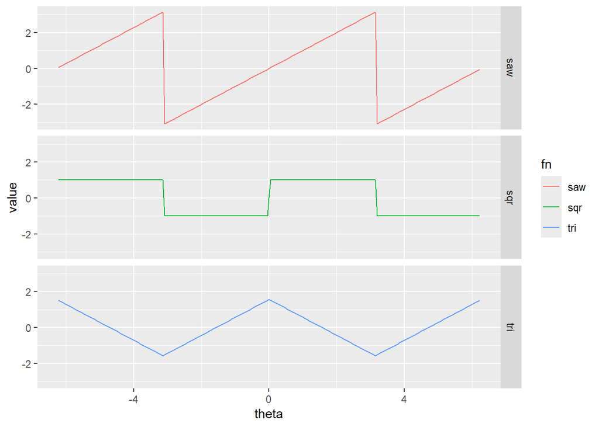

Each function is periodic with period $2 \pi$, and each is piecewise linear. We define these functions as follows, using the previously introduced modular mapping $\theta \mapsto \tilde{\theta} \in (-\pi, \pi]$.

$$\begin{align}
f_\tau (\theta) &= \tilde{\theta} \\
f_\sigma (\theta) &= \text{sgn}(\tilde{\theta}) &=
\begin{cases}
1 & \text{for } \tilde{\theta} > 0 \\
0 & \text{for } \tilde{\theta} = 0 \\
-1 & \text{for } \tilde{\theta} < 0
\end{cases}
\\
f_\Delta (\theta) &= \frac{\pi}{2} - | \tilde{\theta} |
\end{align}$$

The table and figure below give the coefficients of the respective Fourier approximations of these functions, which are derived in the next sections.

Fourier approximation formulas

| function | index | term |
| --- | --- | --- |
| sawtooth | $\; \nu \ge 1 \;$ | $\; 2 (-1)^{\nu - 1} \sin (\nu \theta) / \nu \;$ |
| square wave | $\; (2 \nu - 1) \ge 1 \;$ | $\; 4 \sin ((2 \nu - 1) \theta) / ((2 \nu - 1) \pi) \;$ |
| triangular wave | $\; (2 \nu - 1) \ge 1 \;$ | $\; 4 \cos ((2 \nu - 1) \theta) / ((2 \nu - 1)^2 \pi) \;$ |

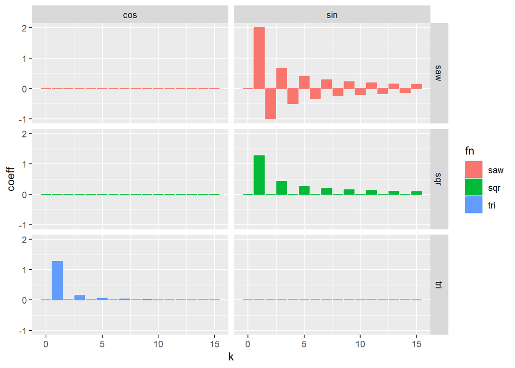

Each of these functions is real-valued and has an average value of zero. The sawtooth and square wave functions are odd, that is, $f(- \theta) = - f(\theta)$, so their Fourier sums can be expressed as sums of sines, with summation index $\nu$ starting at 1. The triangular wave function is even, i.e., $f(- \theta) = f(\theta)$, so its Fourier sum can be expressed as a sum of cosines, again with index $\nu$ starting at 1. Note also that terms of even index $(2 \nu)$ evaluate to zero for the square wave and triangular wave functions.

### Sawtooth coefficients

The Fourier coefficients of the sawtooth function are as follows.

$$\begin{align}
\hat{f} [\nu] &= \left < f, u_\nu \right > \\
&= \frac{1}{2 \pi} \int_{- \pi}^\pi t \times e^{-i \nu t} \; dt \\
&= \frac{1}{2 \pi} \int_{- \pi}^\pi t \times (\cos(\nu t) - i
sin(\nu t)) \; dt
\end{align}$$

Since the term $t \cos (\nu t)$ is an odd function, it integrates to 0 over $(-\pi, \pi]$. Thus we have

$$\begin{align}
\hat{f} [\nu] &= \frac{-i}{2 \pi} \int_{- \pi}^\pi t \times
sin(\nu t) \; dt
\end{align}$$

The integrand is zero for $\nu = 0$. For $\nu \ne 0$ we have

$$\begin{align}
\hat{f} [\nu] &= \frac{-i}{2 \pi} \int_{- \pi}^\pi t \times
sin(\nu t) \; dt \\
&= \frac{-i}{2 \pi} \left [ t \times \frac{- \cos (\nu t)}{\nu}
\right ]_{- \pi}^\pi \\
&= \frac{i}{2 \pi} \left [ t \times \frac{\cos (\nu t)}{\nu}
\right ]_{- \pi}^\pi \\
&= i \; \frac{ (-1)^\nu }{\nu}
\end{align}$$

The approximating Fourier series is thus

$$\begin{align}
S_n(f) \; (\theta) &= \sum_{\nu = -n}^n \hat{f} [\nu] \times u_\nu
(e^{i \theta}) \\
&= \sum_{\nu = 1}^n \left \{ i \frac{(-1)^\nu}{\nu} e^{i \nu
\theta} + i \frac{(-1)^{-\nu}}{-\nu} e^{-i \nu \theta} \right \} \\
&= \sum_{\nu = 1}^n i \frac{(-1)^\nu}{\nu} \left \{ e^{i \nu
\theta} - e^{-i \nu \theta} \right \} \\
&= \sum_{\nu = 1}^n i \frac{(-1)^\nu}{\nu} \left \{ 2 i \sin(\nu
\theta) \right \} \\
&= 2 \sum_{\nu = 1}^n \frac{(-1)^{\nu- 1}}{\nu} \left \{ \sin(\nu
\theta) \right \}
\end{align}$$

### Square wave coefficients

Now we develop the Fourier coefficients of the square wave function.

$$\begin{align}
\hat{f} [\nu] &= \left < f, u_\nu \right > \\
&= \frac{1}{2 \pi} \int_{- \pi}^\pi \text{sgn}(t) \times e^{-i \nu
t} \; dt \\
&= \frac{1}{2 \pi} \int_{- \pi}^\pi \text{sgn}(t) \times (\cos(\nu
t) - i sin(\nu t)) \; dt
\end{align}$$

Since $\text{sgn}(t)$ is an odd function, so is the term $\text{sgn}(t) \times \cos (\nu t)$, which therefore integrates to zero. We thus have

$$\begin{align}
\hat{f} [\nu] &= \frac{-i}{2 \pi} \int_{- \pi}^\pi \text{sgn}(t)
\times sin(\nu t) \; dt
\end{align}$$

The integrand equals zero for $\nu = 0$, whereas for $\nu \ne 0$ we have

$$\begin{align}
\hat{f} [\nu] &= \frac{-i}{\pi} \int_{0}^\pi sin(\nu t) \; dt \\
&= \frac{-i}{\pi} \left [ \frac{- \cos (\nu t)}{\nu}
\right]_{0}^\pi \\
&= \frac{i}{\pi} \left [ \frac{\cos (\nu t)}{\nu} \right]_{0}^\pi
\\
&= \frac{i}{\pi} \left \{ \frac{(-1)^\nu - 1}{\nu} \right \}
\end{align}$$

Consequently

$$\begin{align}
\hat{f} [2 \nu] &= 0 \\
\hat{f} [2 \nu - 1] &= \frac{-2 i}{2 \nu - 1} \\
\hat{f} [-2 \nu + 1] &= \frac{2 i}{2 \nu - 1}
\end{align}$$

Therefore the approximating Fourier series is as follows.

$$\begin{align}
S_{2 n}(f) \; (\theta) &= S_{2 n - 1}(f) \; (\theta) \\
&= \sum_{\nu = -2 n + 1}^{2 n - 1} \hat{f} [\nu] \times u_\nu
(e^{i \theta}) \\
&= \sum_{\nu = 1}^n \left \{
\hat{f} [2 \nu - 1] \; (e^{i (2 \nu - 1) \theta}) \; \
\hat{f} [-2 \nu + 1] \; (e^{-i (2 \nu - 1) \theta}) \right \}
\\
&= \frac{2 i}{\pi} \sum_{\nu = 1}^n \frac{1}{2 \nu - 1}
\left \{-e^{(2 \nu - 1) i \theta} \; + \; e^{(-2 \nu + 1) i \theta}
\right \} \\
&= \frac{2 i}{\pi} \sum_{\nu = 1}^n \frac{- 2 i \sin((2 \nu - 1)
\theta)}{(2 \nu - 1} \\
&= \frac{4}{\pi} \sum_{\nu = 1}^n \frac{\sin((2 \nu - 1)
\theta)}{(2 \nu - 1}
\end{align}$$

### Triangular wave coefficients

Finally we develop the Fourier coefficients of the triangular wave function.

$$\begin{align}
\hat{f} [\nu] &= \left < f, u_\nu \right > \\
&= \frac{1}{2 \pi} \int_{- \pi}^\pi f(t) \times e^{-i \nu t} \; dt
\\
&= \frac{1}{2 \pi} \int_{- \pi}^\pi \left ( \frac{\pi}{2} - |t|
\right ) \times e^{-i \nu t} \; dt \\
&= \frac{1}{2 \pi} \int_{- \pi}^\pi \left ( \frac{\pi}{2} - |t|
\right ) \; \left ( \cos(\nu t) - i \sin(\nu t) \right ) \; dt
\end{align}$$

Since $f(t)$ is an even function, the term $f(t) \sin(\nu t)$ is an odd function and integrates to zero. Thus

$$\begin{align}
\hat{f} [\nu] &= \frac{1}{2 \pi} \int_{- \pi}^\pi \left (
\frac{\pi}{2} - |t| \right ) \; \cos(\nu t) \; dt
\end{align}$$

For $\nu = 0$ we have

$$\begin{align}
\hat{f} [0] &= \frac{1}{2 \pi} \int_{- \pi}^\pi \left (
\frac{\pi}{2} - |t| \right ) \; dt \\
&= \frac{\pi}{2} - \frac{1}{\pi} \int_{0}^\pi t \; dt \\
&= \frac{\pi}{2} - \frac{1}{\pi} \left [ \frac{t^2}{2} \right
]_{0}^\pi \\
&= 0
\end{align}$$

For $\nu \ne 0$ we have

$$\begin{align}
\hat{f} [\nu] &= \frac{1}{2 \pi} \int_{- \pi}^\pi \left (
\frac{\pi}{2} - |t| \right ) \; \cos(\nu t) \; dt \\
&= \frac{1}{4} \int_{- \pi}^\pi \cos(\nu t) \; dt \; - \;
\frac{1}{2 \pi} \int_{- \pi}^\pi |t| \; \cos(\nu t) \; dt \\
&= 0 \; - \; \frac{1}{2 \pi} \int_{- \pi}^\pi |t| \; \cos(\nu t)
\; dt \\
&= - \frac{1}{\pi} \int_{0}^\pi t \; \cos(\nu t) \; dt
\end{align}$$

Integration by parts now yields

$$\begin{align}
\hat{f} [\nu] &= - \frac{1}{\pi} \int_{0}^\pi t \; \cos(\nu t) \;
dt \\
&= - \frac{1}{\pi} \left [ t \frac{\sin(\nu t)}{\nu} \right
]_{0}^\pi \; + \;
\frac{1}{\pi} \int_{0}^\pi \frac{\sin(\nu t)}{\nu} \; dt \\
&= 0 \; + \; \frac{1}{\pi} \int_{0}^\pi \frac{\sin(\nu t)}{\nu} \;
dt \\
&= \frac{1}{\pi} \left [ \frac{- \cos(\nu t)}{\nu^2} \right
]_{0}^\pi \\
&= \frac{1}{\pi \nu^2} \left \{ (-1)^{\nu + 1} + 1 \right \}
\end{align}$$

Consequently we have

$$\begin{align}
\hat{f} [2 \nu] &= 0 \\
\hat{f} [2 \nu - 1] &= \hat{f} [-2 \nu + 1] \\
&= \frac{2}{\pi (2 \nu - 1)^2}
\end{align}$$

Therefore the approximating Fourier series is as follows.

$$\begin{align}
S_{2 n} (f) \; (\theta) &= S_{2 n - 1} (f) \; (\theta) \\
&= \sum_{\nu = -2 n + 1}^{2 n - 1} \hat{f} [\nu] \; u_\nu (e^{i
\theta}) \\
&= \sum_{\nu = 1}^n \hat{f} [2 \nu - 1] \; \left \{ e^{i (2 \nu -
1) \theta} + e^{i (-2 \nu + 1) \theta} \right \} \\
&= \frac{2}{\pi} \sum_{\nu = 1}^n \frac{1}{(2 \nu - 1)^2} \; 2
\cos ((2 \nu - 1) \theta) \\
&= \frac{4}{\pi} \sum_{\nu = 1}^n \frac{ \cos ((2 \nu - 1) \theta)
}{ (2 \nu - 1)^2 }
\end{align}$$

## Gibbs Phenomenon

The figure below shows the Fourier series approximation $S_n(f) (\theta)$ for the sawtooth function, with the number of terms $n$ set to 9, 25, respectively.

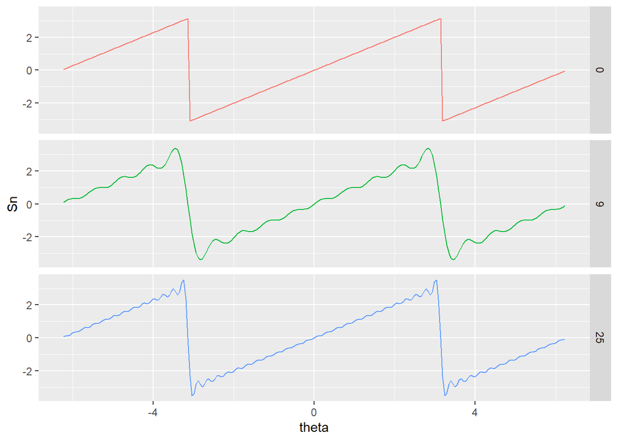

The original sawtooth function $f(\theta)$ is shown in the top panel. The 9-term and 25-term approximations, $S_{9} (f)$ and $S_{25} (f)$, are show in the subsequent panels.

Note that $f(\theta)$ has a jump discontinuity at odd multiples of $\pi$. The approximations $S_n (f)$ improve with increasing $n$, except at these points of discontinuity. Near these points the approximation error converges to about 9% of the jump magnitude ($2 \pi$ in this case).

This persistent error at jump discontinuities is known as Gibbs phenomenon, named after Josiah Willard Gibbs.

For the sawtooth function, the Gibbs phenomenon prevents convergence of $S_n (f)$ to $f(\cdot)$ in the $L_\infty$ norm. In the 2-norm, however, $S_n (f)$ converges to $f(\cdot)$ for all $f(\cdot) \in L_2(\mathbb{T})$, as previously noted. (The 3 example functions presented here are all bounded, and thus members of $L_p(\mathbb{T})$ for all $p$.)

## Kernel Functions

We previoiusly introduced weighted sums $S_{n, w} (f)$ of Fourier terms, which can be expressed as the following convolution with $f (\cdot)$.

$$\begin{align}
S_{n, w} (f) (\theta) &= \sum_{\nu = n}^n w_n [\nu] \; \hat{f}
[\nu] \; e^{i \nu \theta} \\
&= \sum_{\nu = n}^n w_n [\nu] \; \left ( \frac{1}{2 \pi} \int_{-
\pi}^{\pi} f(t) \times e^{- i \nu t} \; dt \right ) \; e^{i \nu \theta}
\\
&= \frac{1}{2 \pi} \int_{- \pi}^{\pi} \left ( \sum_{\nu = n}^n w_n
[\nu] \; e^{i \nu (\theta - t)} \right ) f(t) \; dt \\
&= \frac{1}{2 \pi} \int_{- \pi}^{\pi} W_n (\theta - t) \; f(t) \;
dt \\
&= \left ( W_n * f \right ) (\theta)
\end{align}$$

where the kernel function $W_n (\cdot)$ is the Fourier transform of the weight coefficients.

$$\begin{align}
W_n (\alpha) = \sum_{\nu = -n}^n w_n [\nu] \; e^{i \nu \alpha}
\end{align}$$

### Dirichlet kernel function

In the case of uniform unit weights, $w_n [\cdot] \equiv 1$, we have $S_{n, w} (f) = S_n (f)$ and $W_n (\cdot) = D_n (\cdot)$, where $D_n (\cdot)$ is the Dirichlet kernel function.

$$\begin{align}
D_n (\alpha) &= \sum_{\nu = -n}^n e^{i \nu \alpha} \\
&= 1 + 2 \sum_{\nu = 1}^n cos( \nu \alpha ) \\
&= \frac{ sin \left ( (n + 1/2) \alpha \right ) }{ sin(\alpha / 2)
}
\end{align}$$

The figure below shows $D_n (\theta)$ for $n =$ 9, 25, and for $\theta \in (-2 \pi, 2 \pi)$.

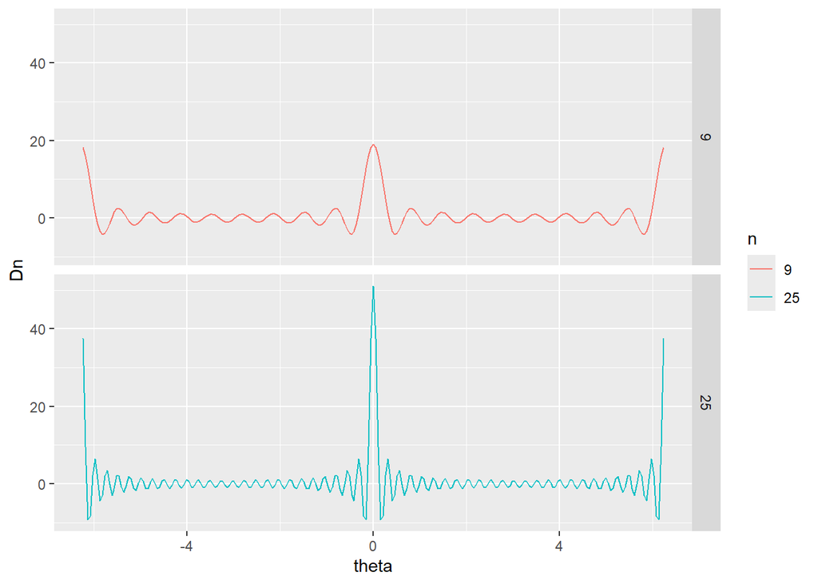

As the kernel index $n$ increases, $D_n (\cdot)$ is increasingly concentrated near $\theta \equiv 0$ mod $2 \pi$. Moreover, from the original definition of $D_n (\cdot)$ as a sum of unitary exponential functions, we see that $D_n (\cdot)$ integrates to unity on $\mathbb{T}$ with respect to measure $\lambda_\mathbb{T}$.

Since $D_n (\cdot)$ is concentrated near 0 mod $2 \pi$ and integrates to unity on $\mathbb{T}$, $S_n (f) (\theta)$ converges to $f (\theta)$ if $f (\cdot)$ is continuous in a neighborhood of $\theta$. But as previuosly noted, if $f (\cdot)$ has a jump discontinuity at $\theta$, then $S_n (f) (\theta)$ incurs an error near $\theta$ whose magnitude, for all $n$, is approximately 9% of the magnitude of the jump (Gibbs phenomenon).

### Fejér kernel function

One way to mitigate Gibbs phenomenon is to take the average of successive Fourier series approximations.

$$\begin{align}
A_n (f) \; (\theta) &= \frac{1}{n} \sum_{k = 0}^{n-1} S_k (f) \;
(\theta)
\end{align}$$

This turns out to be equivalent to the following weighted sum of Fourier terms.

$$\begin{align}
A_n (f) \; (\theta) &= \frac{1}{n} \sum_{k = 0}^{n-1} S_k (f) \;
(\theta) \\
&= \frac{1}{n} \sum_{k = 0}^{n-1} \sum_{\nu = -k}^{k}
\hat{f} [\nu] \; e^{i \nu \theta} \\
&= \frac{1}{n} \sum_{\nu = -n + 1}^{n-1} (n - |\nu|) \;
\hat{f} [\nu] \; e^{i \nu \theta} \\
&= \sum_{\nu = -n + 1}^{n-1} \left ( 1 - \frac{|\nu|}{n} \right )
\;
\hat{f} [\nu] \; e^{i \nu \theta}
\end{align}$$

Expanding $\hat{f} [\nu]$ as an integral, $A_n (f) (\theta)$ can be re-expressed as follows.

$$\begin{align}
A_n (f) \; (\theta) &= \sum_{\nu = -n + 1}^{n-1} \left ( 1 -
\frac{|\nu|}{n} \right ) \;
\hat{f} [\nu] \; e^{i \nu \theta} \\
&= \sum_{\nu = -n + 1}^{n-1} \left ( 1 - \frac{|\nu|}{n}
\right ) \;
\left ( \frac{1}{2 \pi} \int_{- \pi}^{\pi} f(t) \times e^{- i \nu
t} \; dt \right )
\times e^{i \nu \theta} \\
&= \frac{1}{2 \pi} \int_{- \pi}^{\pi} f(t) \times \sum_{\nu =
-n + 1}^{n - 1}
\left ( 1 - \frac{|\nu|}{n} \right ) \; e^{i \nu (\theta - t)} \;
dt \\
&= \frac{1}{2 \pi} \int_{- \pi}^{\pi} f(t) \times F_n (\theta
- t) \; dt
\end{align}$$

where $F_n (\cdot)$ denotes the Fejér kernel function, named after the Hungarian mathematician Lipót Fejér.

$$\begin{align}
F_n(\theta) &= \sum_{\nu = -n + 1}^{n-1} \left ( 1 -
\frac{|\nu|}{n} \right ) e^{i \nu \theta}
\end{align}$$

Note that

$$\begin{align}
& {\left | \sum_{\mu = 0}^{n-1} e^{i \mu \theta} \right |}^2 \\
&= \sum_{\mu = 0}^{n-1} e^{i \mu \theta} \; \sum_{\nu = 0}^{n-1}
e^{-i \nu \theta} \\
&= \sum_{\mu = 0}^{n-1} \; \sum_{\nu = 0}^{n-1} e^{i (\mu - \nu)
\theta} \\
&= \sum_{k = -n + 1}^{n-1} (n - |k|) \; e^{i k \theta} \\
&= n \; F_n (\theta)
\end{align}$$

so that

$$\begin{align}
F_n (\theta) &= \frac{1}{n} \; {\left | \sum_{\mu = 0}^{n-1} e^{i
\mu \theta} \right |}^2 \\
&= \frac{1}{n} \; {\left | \frac{1 - e^{i n \theta}}{1 - e^{i
\theta}} \right |}^2 \\
&= \frac{1}{n} \; \left( \frac{\sin(n \; \theta / 2)}{\sin(\theta
/ 2)} \right )^2
\end{align}$$

The figure below shows $F_n(\theta)$ for $n =$ 9, 25, and for $\theta \in (- 2 \pi, 2 \pi)$.

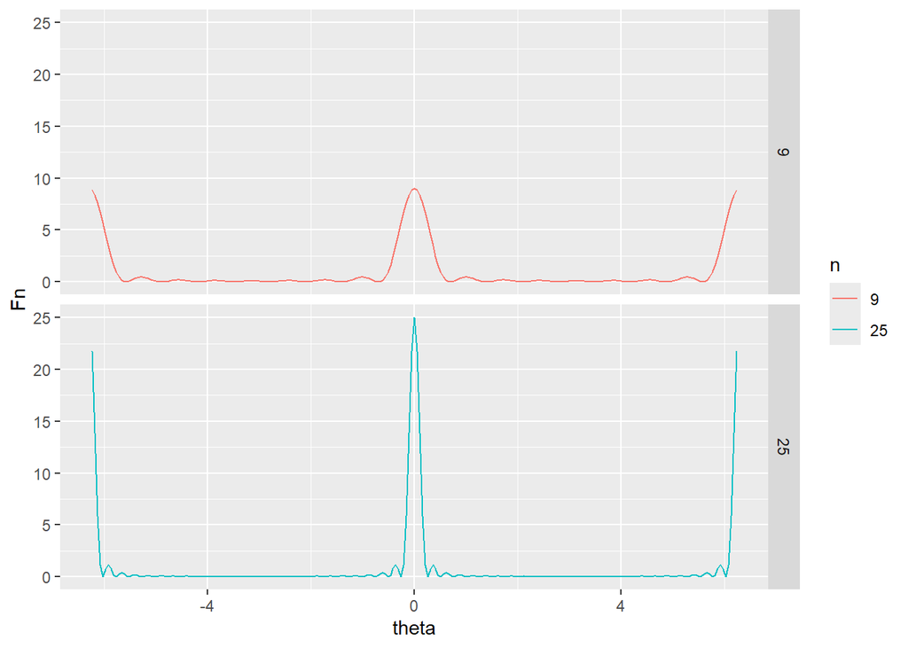

The following figure compares convolution of the sawtooth function with the Dirichlet kernel and with the Fejér kernel, respectively. (The top row, with a nominal index of zero, shows the sawtooth function itself.)

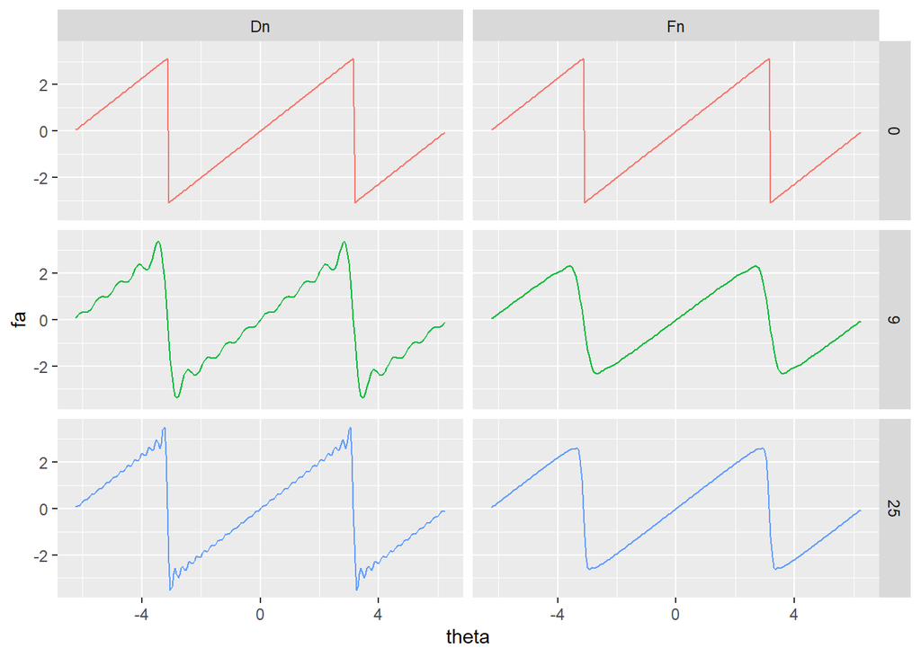

As shown in the figure above, replacing the Dirichlet kernel with the Fejér kernel mitigates the Gibbs phenomenon, as desired.

### Kernels as transformed windows

The Dirichlet and Fejér kernel functions exemplify the following general construction of a kernel function. For $u \in [-1, 1]$ we define some continuous “window” function $mathcal{w} (u)$ and then for each positive integer $k$ we define a discrete sampling of $mathcal{w} (\cdot)$. That is, for integer $|k| \le K$ we define

$$\begin{align}
w_K [k] = \mathcal{w} (\frac{k}{K})
\end{align}$$

We then define a modified Fourier series approximation to a given function $f(\cdot)$ as

$$\begin{align}
S_{K, w} (f) \; (\theta) &= \sum_{k = -K}^K w_K (k) \times
\hat{{f} [k] \times e^{i k \theta} \\
&= \frac{1}{2 \pi} \int_{- \pi}^\pi f(t) \times \sum_{k = -K}^K
w_K (k) \times e^{i k (\theta - t)} \; dt \\
&= \frac{1}{2 \pi} \int_{- \pi}^\pi f(t) \times W_K (\theta - t)
\; dt \\
&= \left ( f * W_K \right ) (\theta)
\end{align}$$

where

$$\begin{align}
W_K (\theta) &= \sum_{k = -K}^K w_K [k] \times e^{i k \theta}
\end{align}$$

For the Dirichlet kernel function $D_K (\cdot)$, the window function is $\mathcal{w}_D (u) = 1$ over the interval $u \in [-1, 1]$. For the Fejér kernel function $F_K (\cdot)$ we have $\mathcal{w}_F (u) = 1 - |u|$.

The window function $\mathcal{w} (\cdot)$ is usually defined to be an even, non-negative function such that $\mathcal{w} (0) = 1$ with $ (u)$ decreasing on $u \in [0, 1]$, so as to dampen the higher harmonics of $f (\cdot)$. Such window functions are also called “convergence factors” or “tapering functions”.

### Hann kernel function

The Hann window is defined from the following window function $\mathcal{w} (\cdot)$.

$$\begin{align}
\mathcal{w} (u) &= \frac{1 + \cos(\pi u)}{2} \\
&= \cos^2 \left ( \frac{\pi}{2} u \right )
\end{align}$$

The discrete window functino $w_K [k]$ is thus

$$\begin{align}
w_K [k] &= \frac{1 + \cos(\frac{\pi k}{K})}{2} \\
&= \cos^2 \left ( \frac{\pi k}{2 K} u \right )
\end{align}$$

Taking the Fourier transform we have

$$\begin{align}
W_K (\theta) &= sum_{k = -K}^K w_K [k] \times e^{i k \theta} \\
&= sum_{k = -K}^K \frac{1 + \cos( \frac{\pi k}{K} )}{2} \times
e^{i k \theta} \\
&= \frac{1}{2} D_K (\theta) \; + \; \frac{1}{2} sum_{k = -K}^K
\cos \left( \frac{\pi k}{K} \right ) \times e^{i k \theta} \\
&= \frac{1}{2} D_K (\theta) \; + \; \frac{1}{4} sum_{k = -K}^K
\left( e^{i \pi k / K} + e^{-i \pi k / K} \right ) \times e^{i k \theta}
\\
&= \frac{1}{2} D_K (\theta) \; + \; \frac{1}{4} D_K \left ( \theta
+ \frac{\pi}{K} \right ) \; + \; \frac{1}{4} D_K \left ( \theta -
\frac{\pi}{K} \right )
\end{align}$$

Computing the shift of argument $\theta$ by $\frac{\pi}{K}$ can be facilitated by ensuring that $\frac}{\pi}{K}$ is among the sampled $\theta-$values. That is, if the interval $[0, \2 \pi)$ is sampled at $n_\theta$ evently spaced grid points

$$\begin{align}
\left \{ \theta_\nu = \frac{2 \pi}{n_\theta} \nu \right \}_{\nu =
0}^{n_\theta - 1}
\end{align}$$

then we’ll want $n_\theta$ to satisfy

$$\begin{align}
\frac{\pi}{K} = m \times \frac{2 \pi}{n_\theta}
\end{align}$$

for some positive integer $m$. Thus we want to set $n_\theta = 2 m \times K$.

The figure below shows the Hann kernel $H_K (\theta)$ for $K =$ 3, and for $\theta \in (-2 \pi, 2 \pi)$. On close inspection one can see that the function is negative for $\theta$ near $\{ \pm 2.4, \pm 3.9 \}$.

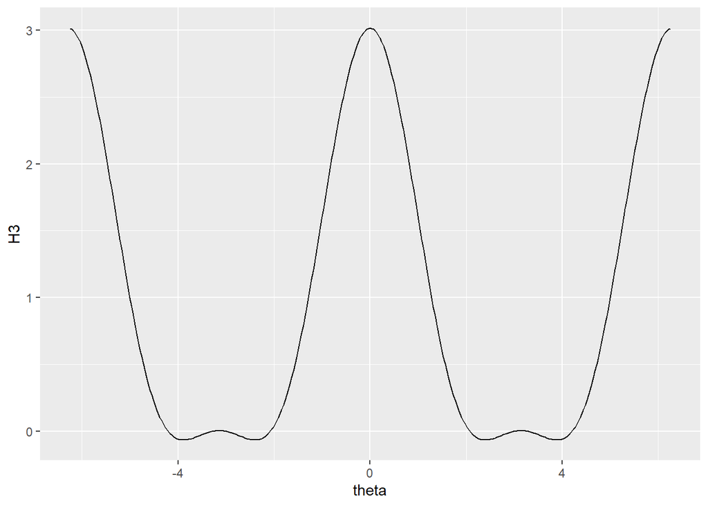

The next figure below shows the Hann kernel $H_n (\theta)$ for $n =$ 9, 25.

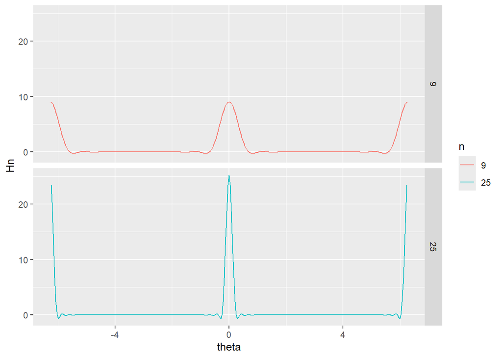

When the Hann kernel is convolved with a function $f (\cdot)$, the negative side lobes of the Hann kernel can mar the desired performance. To reduce this problem, similar kernel functions, but non-negative for all $\theta$, were developed by Blackman, Hamming, and others.

## DFT: the discrete Fourier transform

Thus far we have considered a few simple functions, each one given by a formula. We then derived formulas for the Fourier coefficients of each functions, and applied thos formulas to compute Fourier approximations to the respective functions. The appproximations were again expressed as formulas. In order to display the original function $f (\theta)$ and an approximation $S_{n, w} (f) \; (\theta)$, we applied the formula at a discrete set of $\theta$-values.

### Frequency grid-points

Another approach to Fourier approximation of a $2 \pi$-periodic function $f (\cdot)$ is to start with functional values at a pre-defined set of $\theta$-values of the form

$$\begin{align}
f_\bullet = f(\theta_\bullet) = \left \{ f(\theta_\nu) \right \}_{\nu
= 0}^{n_\theta - 1}
\end{align}$$

where $\theta_bullet = \theta_\nu$ ranges over a grid of points spanning $[0, 2 \pi)$

$$\begin{align}
\theta_\nu = \frac{2 \pi}{n_\theta} \times \nu
\end{align}$$

so that

$$\begin{align}
\theta_0 &= 0 \\
\theta_1 &= \frac{2 \pi}{n_\theta} \\
\theta_\nu &= \theta_1 \times \nu
\end{align}$$

Now let $\omega_n$ denote the $n^{th}$ primitive root of unity

$$\begin{align}
\omega_n = \exp \left( \; i \; \frac{2 \pi}{n} \; \right )
\end{align}$$

so that

$$\begin{align}
\omega_{n_\theta} &= \exp \left( \; i \; \frac{2 \pi}{n_\theta} \;
\right ) \\
&= e^{i \theta_1 \;}
\end{align}$$

Then the discrete Fourier transform of $f (\cdot)$ is computed as follows.

$$\begin{align}
\text{DFT} (f) \; \left ( \omega_{n_theta}^k \right )
&= \sum_{\nu = 0}^{n_\theta - 1} f(\theta_\nu) \times
\omega_{n_\theta}^{- k \nu} \\
&= \sum_{\nu = 0}^{n_\theta - 1} f(\theta_\nu) \times e^{-i k
\theta_\nu} \\
\\
& \text{for } k \in \{ 0, 1, 2, \ldots, n_{\theta - 1} \}
\end{align}$$

Thus we have two equivalent sets of grid points over $mathbb{T}$ and over $[0, 2 \pi)$, respectively.

$$\begin{align}
\left \{ \omega_{n_\theta}^k \right \}_{k = 0}^{n_\theta - 1}
&\subset \mathbb{T} \\
\\
\left \{ \theta_\nu \right \}_{\nu = 0}^{n_\theta - 1} &\subset
[0, 2 \pi)
\end{align}$$

The equivalence of the two sets of grid-points turns out to be advantageious, both mathematically and computationally.

### Approximate Fourier coefficients

The mathematical convenience of matching the $\omega$ grid points to the $\theta$ grid points is due to the following approximation.

$$\begin{align}
\frac{1}{n_\theta} \text{DFT} (f) \; \left ( \omega_{n_\theta}^k
\right ) \\
&= \frac{1}{n_\theta} \sum_{\nu = 0}^{n_\theta - 1} f(\theta_\nu)
\times e^{- i k \theta_\nu} \\
&= \frac{1}{2 \pi} \sum_{\nu = 0}^{n_\theta - 1} f(\theta_\nu)
\times e^{- i k \theta_\nu} \times \frac{2 \pi}{n_\theta} \\
&\approx \frac{1}{2 \pi} \int_0^{2 \pi} f(\theta) \times e^{-i k
\theta} d\theta \\
&= \hat{f} [k]
\end{align}$$

If $f (\cdot)$ is Riemann integrable, the approximation error tends to zero as $n_\theta$ increases. We denote this asymptotic relationship as follows.

$$\begin{align}
\text{DFT} (f) \; \left ( \omega_{n_theta}^k \right ) &\sim
n_\theta \times \hat{f} [k]
\end{align}$$

### Discrete symmetry

For any positive integer $n$ we have $\omega_n^n = e^{i \2 \pi} = 1$. Thus

$$\begin{align}
\omega_{n_\theta}^{n_\theta - k} &= \omega_{n_\theta}^{n_\theta}
\; \omega_{n_\theta}^{-k} \\
&= \omega_{n_\theta}^{-k}
\end{align}$$

Consequently for $k \in (n_\theta / 2, n_\theta)$ we have

$$\begin{align}
\text{DFT} (f) \; \left ( \omega_{n_theta}^{n_\theta - k} \right )
&= \text{DFT} (f) \; \left ( \omega_{n_theta}^{- k} \right ) \\
&\sim n_\theta \times \hat{f} [-k]
\end{align}$$

This relationship is an artifact of discrete sampling. That is, for $k \in (n_\theta / 2, n_\theta)$ DFT values correspond to Fourier coefficients at negative indices.

### Matrix representation

Continuing to use the notation above, we have $n_\theta$ grid points $\{ \theta_\nu \}$ along the interval $[0, 2 \pi)$ with

$$\begin{align}
\theta_\nu &= \frac{2 \pi}{n_\theta} \nu & \text{for } 0 \le
\nu < n_\theta \\
\\
\omega_{n_\theta} &= e^{i \theta_1} \\
&= e^{i \frac{2 \pi}{n_\theta}}
\end{align}$$

In order to represent $DFT(f)$ as a matrix-vector product, we introduce the following vector notation for $\{ \theta_nu \}$ and $\{ f(\theta_nu) \}$.

$$\begin{align}
\theta_\bullet &= \left ( \theta_\nu \right )_{\nu = 0}^{n_\theta
- 1} \\
\\
&=
\begin{pmatrix}
\theta_0 \\
\theta_1 \\
\theta_2 \\
\vdots \\
\theta_{n_\theta - 1}
\end{pmatrix}
\end{align}$$

$$\begin{align}
f_\bullet = (\theta_\bullet) &= \left ( f(\theta_\nu) \right
)_{\nu = 0}^{n_\theta - 1} \\
\\
&=
\begin{pmatrix}
f(\theta_0) \\
f(\theta_1) \\
f(\theta_2) \\
\vdots \\
f(\theta_{n_\theta - 1})
\end{pmatrix}
\end{align}$$

Now let matrix $\Omega$ be defined as follows.

$$\begin{align}
\Omega = \Omega_{n_theta} &= \left ( \omega_{n_\theta}^{\mu \;
\nu} \right )_{\mu, \nu = 0}^{n_\theta - 1} \\
\\
&=
\begin{pmatrix}
\omega_{n_\theta}^0 & \omega_{n_\theta}^0 &
\omega_{n_\theta}^0 & \ldots & \omega_{n_\theta}^0 \\
\omega_{n_\theta}^0 & \omega_{n_\theta}^1 &
\omega_{n_\theta}^2 & \ldots & \omega_{n_\theta}^{n_\theta - 1}
\\
\omega_{n_\theta}^0 & \omega_{n_\theta}^2 &
\omega_{n_\theta}^4 & \ldots & \omega_{n_\theta}^{2 (n_\theta -
1)} \\
\vdots & \vdots & \vdots & \ddots & \vdots \\
\omega_{n_\theta}^0 & \omega_{n_\theta}^{n_\theta - 1} &
\omega_{n_\theta}^{2 (n_\theta - 1)} & \ldots &
\omega_{n_\theta}^{(n_\theta - 1)^2}
\end{pmatrix}
\end{align}$$

The the DFT can be represented as the matrix-vector product $\bar{\Omega} \times f_\bullet$.

$$\begin{align}
DFT (f) \equiv \bar{\Omega} \times f_\bullet \\
\\
\text{where } \bar{\Omega} &= \left ( \bar{\omega}_{n_\theta}^{\mu
\; \nu} \right ) = \left ( \omega_{n_\theta}^{- \mu \; \nu} \right )
\end{align}$$

Note that $\Omega$ is a symmetric matrix, whose distinct columns are orthogonal to one another.

$$\begin{align}
\left < \Omega [\cdot, \mu], \; \Omega [\cdot, \nu] \right >
&= \sum_{k = 0}^{n_\theta - 1} \omega_{n_\theta}^{k \mu}
\omega_{n_\theta}^{-k \nu} \\
&= \sum_{k = 0}^{n_\theta - 1} \omega_{n_\theta}^{k (\mu - \nu)}
\\
&=
\begin{cases}
n_\theta & \text{if } \mu = \nu \\
0 & \text{otherwise}
\end{cases}
\end{align}$$

Consequently,

$$\begin{align}
\Omega^* \times \Omega &= n_theta \times I
\end{align}$$

where $I$ denotes the identity matrix, and $A^*$ denotes the conjugate transpose of matrix $A$. Since $\Omega$ is symmetric we have

$$\begin{align}
\Omega^* &= \bar{\Omega}
\end{align}$$

Therefore

$$\begin{align}
\Omega^{-1} &= \frac{1}{n_\theta} \Omega^* \\
&= \frac{1}{n_\theta} \bar{\Omega}
\end{align}$$

so that

$$\begin{align}
\bar{\Omega}^{-1} &= \frac{1}{n_\theta} \Omega
\end{align}$$

Note, however, that the inverse discrete Fourier transform (IDFT) is defined as the multiiplication of vector $f_\bullet$ by matrix $\Omega$ rather than $\Omega / n_\theta$.

Also note that a matrix-vector product $A v \in \mathbb{R}^n$ generally requires on the order of $n^2$ arithmetic operations, denoted $O(n^2)$. But computing the DFT requires only $O(n \log n)$ operations due to the special structure of matrix $\Omega$ and due to the advent of the fast Fourier transform (FFT).

### Window functions

Previously we used a window function $\mathcal{w} (\cdot)$ as a convergence factor to reduce the higher-order Fourier coefficients of function $f (\cdot)$ and thereby obtain a smooth approximation $S_{n, w} (f)$ of $f (\cdot)$.

To apply this idea with the DFT context, we must keep in mind the symmetries due to the discrete sampling of $\theta$ and $\omega$.

$$\begin{align}
\theta_{n_\theta - \nu} &= \frac{2 \pi}{n_\theta} (n_\theta - \nu)
\\
&= 2 \pi - \theta_\nu \\
&\equiv - \theta_\nu \bmod{2 \pi}
\end{align}$$

$$\begin{align}
\frac{1}{n_\theta} \text{DFT} (f) \; (\omega_{n_\theta}^\nu) &\sim
\begin{cases}
\hat{f} [\nu] & \text{for } \nu \le n_\theta / 2 \\
\hat{f} [\nu - n_\theta] & \text{for } \nu > n_\theta / 2
\end{cases}
\end{align}$$

In light of these symmetries we define

$$\begin{align}
\tilde{\nu} &=
\begin{cases}
\nu & \text{for } \nu le n_\theta / 2 \\
\nu - n_\theta & \text{for } \nu > n_\theta / 2
\end{cases}
\end{align}$$

We should also bear in mind that when we use the FFT, the grid point at which function $f (\theta_nu)$ is sampled match the grid points at which $DFT (f) (\omega_{n_\theta}^\nu)$ is calculated.

Then we can approximate $S_{K, w} (f) (\omega_{n_\theta}^\nu)$ using the following sequence of calculations.

1. $\text{DFT} (f) (\omega_{n_\theta}^\nu)$
2. $\tilde{\nu}$
3. $\hat{f}_\bullet = \left ( w(\frac{\tilde{\nu}}{K}) \times \text{DFT} (f) (\omega_{n_\theta}^\nu) / n_\theta \right )_{\nu = 0}^{n_\theta - 1}$
4. $\text{IDFT} \left ( \hat{f}_\bullet \right )$

Further notes:

1. There is a rich literature on the engineering of windowing functions to meet various criteria.
2. The FFT is most efficient when the length of input vector $f_\bullet$ is highly composite. One way to meet this requirement is to append (“pad”) zeros to $f_\bullet$.
3. The DFT treats the input vector $f_\bullet$ as the sampling of a periodic function whose initial and final sampled values are adjacent. When $f (\cdot)$ is *not* periodic the apparent discontinuity between initial and final values may inflate the high frequency components of the DFT output. This effect can be mitigated by applying a window function to the input vector $f_\bullet$, a practice known as “data tapering”.

### Duplicated input

Recall the previous representation of $DFT (f)$ as the matrix-vector product $\bar{\Omega} \times f_\bullet$. The product is a vector whose length matches that of the input vector.

We illustrated the periodicity of example functions over the interval $(- 2 \pi, 2 \pi]$ spanning *two* periods, consisting of $m = 2$ concatenated copies of the vector $f_\bullet$. We now consider the DFT output of $m$ concatenated copies, say $f_{m, \bullet}$, of vector $f_\bullet$.

$$\begin{align}
f_{m, \bullet} &=
\begin{pmatrix}
f(\theta_\bullet) \\
f(\theta_\bullet) \\
f(\theta_\bullet) \\
\vdots \\
f(\theta_\bullet)
\end{pmatrix}
\end{align}$$

The length of vector $f_{m, \bullet}$ is $M = m \times n_\theta$. The FFT algorithm effectively multiplies $f_{m, \bullet}$ by the complex conjugate of matrix $\Omega_M$, where

$$\begin{align}
\Omega_M &= \left ( \omega^{\mu \; \nu} \right )_{\mu, \nu = 0}^{M
- 1}
\end{align}$$

That is, the FFT output now corresponds to a finer grid of $M$ points $\{ \alpha_j \}$ along $[0, 2 \pi)$, where

$$\begin{align}
\alpha_j &= \frac{2 \pi}{M} \; j
\end{align}$$

Setting $j = \mu \; n_\theta \; + \; \nu$ we have

$$\begin{align}
\alpha_{\mu \; n_\theta \; + \; \nu} &= \frac{2 \pi}{M} \; (\mu \;
n_\theta \; + \; \nu) \\
&= \frac{2 \pi}{m \; n_\theta} \; (\mu \; n_\theta \; + \; \nu) \\
&= \frac{2 \pi}{m} \; (\mu \; + \; \frac{\nu}{n_\theta}) \\
\\
\text{for } {(0 \le \mu < m)} & \text{ and } {(0 \le \nu <
n_\theta)}
\end{align}$$

Thus

$$\begin{align}
\text{DFT} (f_{m, \bullet}) \; (\omega_M^k) \\
&= \sum_{j = 0}^{M - 1} f_{m, \bullet} [j] \times e^{- i \; k \;
\alpha_j} \\
&= \sum_{j = 0}^{M - 1} f_\bullet [j \bmod{n_\theta}] \times exp(-
i k \frac{2 \pi j}{m \; n_\theta}) \\
&= \sum_{\nu = 0}^{n_\theta - 1} f_\bullet [\nu] \times \sum_{\mu
= 0}^{m - 1} exp(- i k \frac{2 \pi}{m \; n_\theta}(\mu \; n_\theta \; +
\; \nu)) \\
&= \sum_{\nu = 0}^{n_\theta - 1} f_\bullet [\nu] \times exp(- i k
\frac{2 \pi}{m \; n_\theta} \nu) \times \sum_{\mu = 0}^{m - 1} exp(- i k
\frac{2 \pi}{m \; n_\theta}\mu \; n_\theta) \\
&= \sum_{\nu = 0}^{n_\theta - 1} f_\bullet [\nu] \times exp(- i
\frac{k}{m} \frac{2 \pi}{n_\theta} \nu) \times \sum_{\mu = 0}^{m - 1}
exp(- i k \frac{2 \pi}{m} \mu)
\end{align}$$

Now if $k$ is not a multiple of $m$, that is, if $k \not \equiv 0 \bmod{m}$, then the second sum evaluates to zero, so that

$$\begin{align}
\text{DFT} (f_{m, \bullet}) \; (\omega_M^k) \\
&= \sum_{\nu = 0}^{n_\theta - 1} f_\bullet [\nu] \times exp(- i
\frac{k}{m} \frac{2 \pi}{n_\theta} \nu) \times \sum_{\mu = 0}^{m - 1}
exp(- i k \frac{2 \pi}{m} \mu) \\
&= \sum_{\nu = 0}^{n_\theta - 1} f_\bullet [\nu] \times exp(- i
\frac{k}{m} \frac{2 \pi}{n_\theta} \nu) \times 0 \\
&= 0 \\
\\
\text{for } k \not \equiv 0 \bmod{m}
\end{align}$$

On the other hand, if $k$ is a multiple of $m$, then each term in the second sum evaluates to unity, so that

$$\begin{align}
\text{DFT} (f_{m, \bullet}) \; (\omega_M^k) \\
&= \sum_{\nu = 0}^{n_\theta - 1} f_\bullet [\nu] \times exp(- i
\frac{k}{m} \frac{2 \pi}{n_\theta} \nu) \times \sum_{\mu = 0}^{m - 1}
exp(- i k \frac{2 \pi}{m} \mu) \\
&= \sum_{\nu = 0}^{n_\theta - 1} f_\bullet [\nu] \times exp(- i
\frac{k}{m} \frac{2 \pi}{n_\theta} \nu) \times m \\
&= m \sum_{\nu = 0}^{n_\theta - 1} f(\frac{2 \pi \nu}{n_\theta})
\times exp(- i \frac{k}{m} \frac{2 \pi}{n_\theta} \nu) \\
&= m \; n_\theta \; \frac{1}{2 \pi} \sum_{\nu = 0}^{n_\theta - 1}
f(\frac{2 \pi \nu}{n_\theta}) \times exp(- i \frac{k}{m} \frac{2
\pi}{n_\theta} \nu) \times \frac{2 \pi}{n_\theta} \\
&\sim M \; \frac{1}{2 \pi} \int_0^{2 \pi} f(\theta) \; exp \left (
-i \frac{k}{m} \theta \right ) \; d\theta \\
&= M \; \hat{f} \left [ \frac{k}{m} \right ] \\
\\
\text{for } k \equiv 0 \bmod{m}
\end{align}$$

Summarizing, we see that

$$\begin{align}
\text{DFT} (f_{m, \bullet}) \; (\omega_M^k) & \;
\begin{cases}
&= 0 & \text{for } k \not \equiv 0 \bmod{m} \\
&\sim M \; \hat{f} \left [ \frac{k}{m} \right ] & \text{for
} k \equiv 0 \bmod{m}
\end{cases}
\end{align}$$

That is, successive $m^{th}$ elements of the output vector correspond to successive Fourier coefficients of $f (\cdot)$, with the remaining elements equal to zero (within rounding error).

### Sawtooth example

The figure below shows the FFT approximation of $S_n (f)$ for $n =$ 9, 25, where the initial approximation is the DFT-IDFT reconstruction of the original input, $f_{m, \bullet}$. These FFT-based approximations are practically the same as the approximations based on mathematical calculations of the Fourier coefficients.

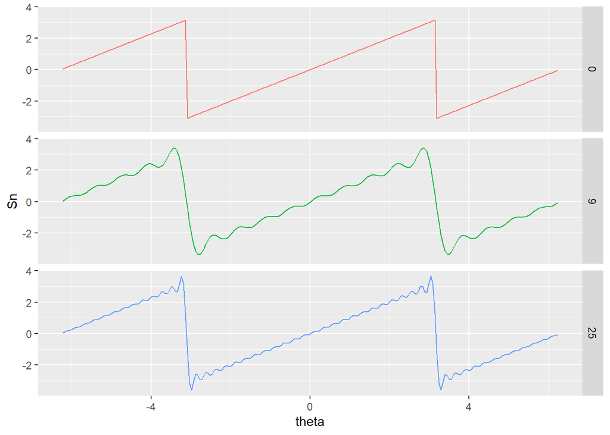

## Closing Remarks

This technical note is intended to serve as a brief refresher on Fourier series in preparation for a subsequent note on the Fourier analysis of time series data. Fourier series approximations to example functions are presented as convolutions with the Dirichlet kernel function $D_n (\cdot)$ and with the Fejér kernel function $F_n (\cdot)$, respectively.

## Glossary of Math Symbols

Glossary of Mathematical Symbols (s)

| s | description |
| --- | --- |
| $\mathcal{B}$ | a Banach space (complete, normed, linear space of functions) |
| $\mathcal{B}^*$ | dual space of bounded linear functionals defined on $\mathcal{B}$ |
| $\mathcal{C} (\mathbb{T})$ | Banach space of continuous functions defined on $\mathbb{T}$ |
| $\mathcal{C}_m (\mathbb{T})$ | Subspace of functions having a continuous derivative of order $m$ |
| $\delta_\tau$ | Dirac delta functional: $\delta_\tau (f) = f (\tau)$ |
| $\mathcal{D}_m (\mathbb{T})$ | dual of $\mathcal{C}_m (\mathbb{T})$ |
| $\mathcal{D}_n (\cdot)$ | Dirichlet kernel function |
| $f (\theta)$ | a periodic function of a real value |
| $\hat{f} [\nu]$ | Fourier coefficient of function $f$ of index $\nu$ |
| $\phi (\omega)$ | a function defined on the unit circle |
| $F_n (\cdot)$ | Fejér kernel function |
| $L_p (\mathbb{T})$ | functions whose p-th power is integrable |
| $\lambda (\cdot)$ | linear functional: linear, scalar-valued function defined on a linear space of functions |
| $\lambda_g (\cdot)$ | linear functional based on function g |
| $\lambda_\mu (\cdot)$ | linear functional based on measure $\mu$ |
| $\hat{\lambda} [\nu]$ | Fourier coefficient of linear functional $\lambda$ of index $\nu$ |
| $\lambda_\mathbb{T}$ | Lebesgue measure on the unit circle scaled to yield unit total mass |
| $\mu (\cdot)$ | a complex-valued Borel measure |
| $\mu_c (\cdot)$ | the component of measure $\mu$ that is absolutely continuous with respect to Lebesgue measure |
| $\mu_d (\cdot)$ | the discrete component of measure $\mu$ concentrated on a countable set of atoms |
| $\| \mu \| \; (\cdot)$ | non-negative measure: modulus of measure $\mu$ |
| $\mathcal{M} (\mathbb{T})$ | Banach space of totally finite Borel measures $\mu (\cdot)$ |
| $\omega$ | a complex number of modulus 1 |
| $\omega_n$ | n-th primitive root of unity, $e^{2 \pi i / n}$ |
| $\Omega$ | a square matrix having elements of the form $\omega_n^{\mu \; \nu}$ |
| $(p, q)$ | conjugate Hölder exponents (having harmonic mean 2) |
| $S_n (f)$ | finite sum of Fourier terms approximating function $f (\cdot)$ |
| $S_{n, w} (f)$ | finite weighted sum of Fourier terms approximating function $f (\cdot)$ |
| $\tilde{\theta}$ | $\theta$ modulo $(- \pi, \pi]$ |
| $\mathbb{T}$ | the unit circle: complex numbers of modulus 1 |
| $u_\nu (\cdot)$ | $e^{i \theta} \mapsto e^{i \nu \theta}$, the unit exponential function of index $\nu$ |
| $\lVert \cdot \rVert$ | norm of a function or linear functional |
| ${\lVert \phi \rVert}_p$ | the p-norm of a function |
| $\left < \phi, \eta \right >$ | inner product of square-integrable functions |

## Resources

### Books

| [An Introduction to Harmonic Analysis (3e)](https://doi.org/10.1017/CBO9781139165372) by Yitzhak Katznelson |
| --- |
| [Harmonic Analysis (2e)](https://doi.org/10.1007/978-93-86279-47-7) by Henry Helson |
| [Time Series (2e)](https://doi.org/10.1137/1.9780898719246) by David Brillinger |

### Articles

| [Cesàro summation](https://en.wikipedia.org/wiki/Cesàro_summation) |
| --- |
| [Fast Fourier transform](https://en.wikipedia.org/wiki/Fast_Fourier_transform) |
| [Fejér kernel](https://en.wikipedia.org/wiki/Fejér_kernel) |
| [Gibbs phenomenon](https://en.wikipedia.org/wiki/Gibbs_phenomenon) |
| [Hann function](https://en.wikipedia.org/wiki/Hann_function) |
| [Hilbert space](https://en.wikipedia.org/wiki/Hilbert_space) |
| [Hölder’s inequality](https://en.wikipedia.org/wiki/Hölder%27s_inequality) |
| [Wiener’s lemma](https://en.wikipedia.org/wiki/Wiener%27s_lemma) |
| [Window function](https://en.wikipedia.org/wiki/Window_function) |